# Homicides by Police in WA since 2015

Next Steps Washington

Everyone Comes Home Alive

Last report update: 2026-11-20

```r
library(tidyverse)
library(plotly)
library(kableExtra)
library(here)
library(leaflet)
library(lubridate)
library(icons)
library(htmlwidgets)
library(janitor)
```

```r
# get cleaned, merged data for WA
load(file = here("Data", "Clean", params$rdafile))

# Data prep (common)
source(here("Analyses", "Common", "waAnalysesPrep.R"))
```

# Introduction

This report tracks the trends in people killed by police in WA since 2015, a period that spans before and after a series of legislative reforms intended to reduce police violence and increase accountability for excessive force and misconduct. A brief overview of these changes is given in the Legislative History section of this report.

## MOST RECENT DATA UPDATE (2026-11-15):

- **Total homicides by police since 2015: 512**
- **Last reported case: David Aaron Bauschman, 54 years old, on November 15, 2026 by Lakewood Police Department, Pierce County Sheriffs Office, Washington State Patrol**

  David Aaron Bauschman is the 39th person killed by police in 2026. The cause of death is reported as vehicle and the manner of death appears to be vehicle accident. This incident involved a police vehicular pursuit. More information can be found in this article: https://komonews.com/news/local/pierce-county-judge-sets-1m-bail-for-20-year-old-accused-of-killing-man-in-dui-crash-spanway-i5-speeding-crime

Before the 2021 legislative reforms, one out of every 6 persons killed in Washington state was killed during an encounter with law enforcement. (On average, about 250 homicide deaths were recorded each year in WA State from 2015-2020, with about 40 killed during encounters with police. You can view and download the state’s official death data [here](https://doh.wa.gov/data-statistical-reports/washington-tracking-network-wtn/death/ach-injury-deaths-dashboard)).

In 2021, the year many reforms passed, the number of people killed by police in Washington dropped by 60%, the largest decline seen in any state. More information on the temporal trends can be found in the section on “Trends over time”.

> *To find out more about what we do or get involved*, please email us at Next Steps Washington

## How to navigate this report

The TOC on the left can be used to navigate through the sections of the report. There are interactive maps with links to media reports, breakdowns by demographics, geography, cause of death, agency and time to provide some insight into the patterns and trends, and a list of all persons killed to acknowledge the lives lost and provide a starting point for those seeking more information on specific cases. Information on the data sources and limitations can be found in the Data sources section. The data and scripts used for this report are available on GitHub, access details can be found in the Public Access section.

## Online information availability

The dataset includes a single url to a news article that is available online. It provides definitive evidence of a fatality, but the information contained in the article should be treated as a place to start research, not as the definitive description of the event. There are often multiple news articles available online, and they may report the conflicting details of the event, as well as conflicting perspectives on the justifiability of the use of lethal force.

Links to these articles are included in this report in the Interactive Map and Say their names sections. When clicked, they will take you to the article.

# Interactive Map

You can click the numbered circles to reach the individual map pointers for each person killed by police.

- *Hovering* over the pointer brings up the name of the person killed and agency of the officer who killed them;
- *Clicking* the pointer will bring up a url to a news article on the case (if available).

```r
popup_text <- homicides %>%
  mutate(url_click_new = paste0("\"", url_click, "\"")) %>%
  select(url_click_new)

map <- leaflet(data = homicides,
               width = "100%") %>%
  addTiles() %>%
  addMarkers( ~ longitude,
              ~ latitude,
              popup = ~ popup_text$url_click_new,
              label = ~ as.character(paste(name, "by", agency)),
              clusterOptions = markerClusterOptions()
              )
map
```

[interactive chart not shown]

# Breakdowns

## Race

### Table

See the “Discussion” tab for more information on how race is ascertained and why the number of missing cases is so high.

```r
tab <- homicides %>%
  mutate(Race = recode_values(as.character(race),
    "AIAN" ~ "American Indian/Alaska Native",
    "ASIA" ~ "Asian",
    "BAA" ~ "Black/African American",
    "HL" ~ "Hispanic/Latinx",
    "MENA" ~ "Middle East/North African",
    "NHPI" ~ "Native Hawaiian/Pacific Islander",
    "WEA" ~ "White/European American",
    default = race),
    Race =  forcats::fct_infreq(Race),
    Race = fct_relevel(Race, "Unknown",
                        after = Inf)
    ) %>%
  group_by(Race) %>%
  summarize(Number = n(),
            Percent = round(100*Number/nrow(homicides), 1)
  ) %>%
  adorn_totals("row")

tab %>%
  kable(caption = "Breakdown by Race") %>%
  kable_styling(bootstrap_options = c("striped","hover")) %>%
  row_spec(which(tab$Race == "Total"), bold = T) %>%
  row_spec(which(tab$Race == "Unknown"), italic = T) %>%
  add_footnote(label = "Percents may not sum to 100 due to rounding",
               notation = "symbol")
```

Breakdown by Race

| Race | Number | Percent |
| --- | --- | --- |
| White/European American | 254 | 49.6 |
| Hispanic/Latinx | 78 | 15.2 |
| Black/African American | 67 | 13.1 |
| American Indian/Alaska Native | 21 | 4.1 |
| Asian | 18 | 3.5 |
| Native Hawaiian/Pacific Islander | 9 | 1.8 |
| Unknown | 65 | 12.7 |
| Total | 512 | 100.0 |

* Percents may not sum to 100 due to rounding

### Plots

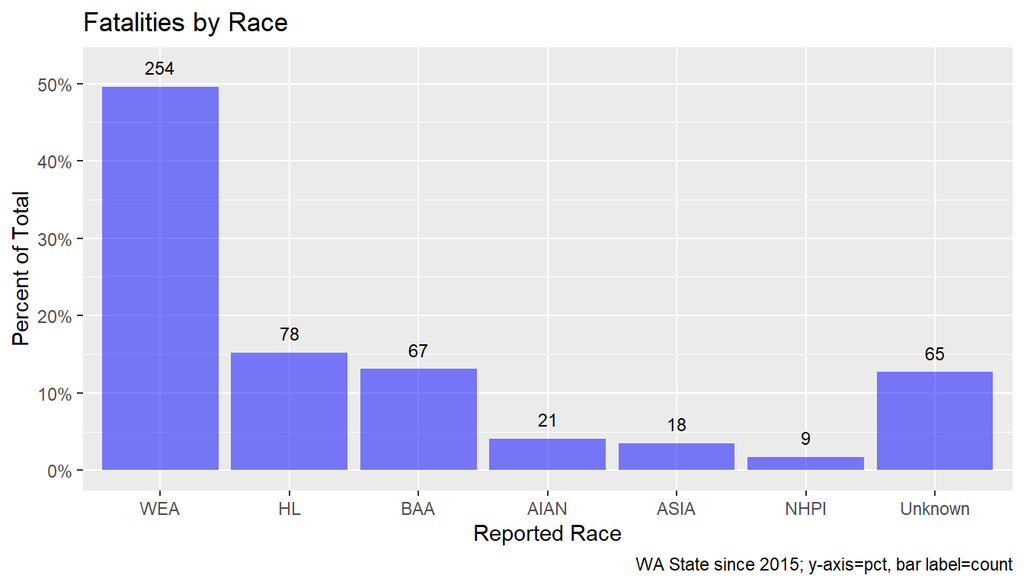

```r
# Detailed race

tab <- homicides %>%
  mutate(Race =  forcats::fct_infreq(race),
         Race = fct_relevel(Race, "Unknown",
                   after = Inf)
         ) %>%
  count(Race) %>%
  mutate(Percent = n / nrow(homicides))# %>%

tab %>% #filter(Race != "Total") %>%
  ggplot(aes(x=Race,
             y = Percent,
             label = n)) +
  geom_bar(stat="identity", fill="blue", alpha=.5) +
  geom_text(aes(y = Percent), size = 3, nudge_y = .025) +

  #theme(axis.text.x = element_text(size=5.5)) +

  scale_y_continuous(labels = scales::percent_format(acc=1)) +

  labs(title = "Fatalities by Race",
       caption = paste0("WA State since ",
                        params$from,
                        "; y-axis=pct, bar label=count")) +
         xlab("Reported Race") +
         ylab("Percent of Total")
```

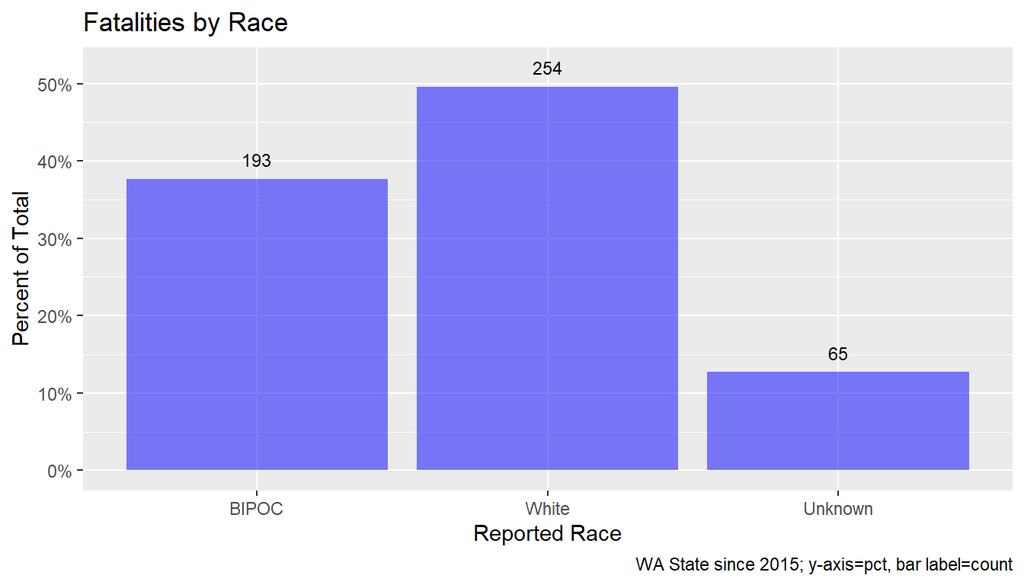

```r
# White vs. BIPOC

homicides %>%
  mutate(raceb = recode_values(race,
                               "WEA" ~ "White",
                               "Unknown" ~ "Unknown",
                               default =  "BIPOC"),
         raceb = fct_relevel(raceb, "Unknown",
                             after = Inf)) %>%
  count(raceb) %>%
  mutate(perc = n / nrow(homicides)) %>%
  ggplot(aes(x=raceb,
             y = perc,
             label = n)) +
  geom_text(aes(y = perc), size = 3, nudge_y = .025) +
  geom_bar(stat="identity", fill="blue", alpha=.5) +

  scale_y_continuous(labels = scales::percent_format(acc=1)) +

  labs(title = "Fatalities by Race",
       caption = paste0("WA State since ",
                        params$from,
                        "; y-axis=pct, bar label=count")) +
  xlab("Reported Race") +
  ylab("Percent of Total")
```

### Discussion

Racial disparities in the risk of being killed by police are one of the most important factors driving the public demand for police accountability and reform. For that reason it is important to understand how these numbers can, and cannot be used.

**TL;DR** While there are many uncertainties in the data that make it difficult/impossible to know the exact numbers, it is clear that the relative risk of being killed by police in WA is higher for people of color.

#### How is race identified in our data?

All crowd-sourced datasets rely primarily on media reports to find cases, and these media reports rarely include information on the race of the person killed. Each of the projects that provide data for this report has made additional efforts made to identify the race of the victim.

- MPV

The MPV project makes extensive additional efforts to identify the race of the person killed. From [their data methodology page](https://mappingpoliceviolence.us/aboutthedata):

> Our data has been meticulously sourced from official police use of force data collection programs in states like California, Texas and Virginia, combined with nationwide data from The Gun Violence Archive and the Fatal Encounters database, two impartial crowdsourced databases. We’ve also done extensive original research to further improve the quality and completeness of the data; searching social media, obituaries, criminal records databases, police reports and other sources to identify the race of 90 percent of all victims in the database.
- Fatal Encounters

The FE project used a statistical imputation model to predict race for the missing cases. A brief description of the methodology is online [here](https://docs.google.com/spreadsheets/d/1dKmaV_JiWcG8XBoRgP8b4e9Eopkpgt7FL7nyspvzAsE/edit#gid=1359780841&range=A9). They were able to impute just over half of the missing cases with reasonable confidence, and we use these imputations for the FE data in this report.

- Incarcernation

The IN project do not provide a description of the methods they use for coding race, but their records typically include information on the race of the person killed, as well as a photo.

- WA local

The local project conducts a search for coroner/ME reports, obituaries, multiple media reports and social media channels for information that can be used to assign the race of the person killed.

#### How often is race missing in our data?

We use a hierarchical assignment of race for the data in this report: MPV data when available, IN data when available, WA local data for cases not included in MPV or IN, and Fatal Encounters (FE) with imputation for cases uniquely contributed by FE.

```r
tab <- homicides %>%
  mutate(race = factor(race),
         Race = fct_relevel(race, "Unknown", after = Inf)) %>%
  group_by(Race, Source=source) %>%
  count()  %>%

  pivot_wider(names_from = Race, values_from = n) %>%
  ungroup() %>%
  mutate(across(where(is.numeric), ~replace_na(., 0))) %>%

  add_row(Source = "Total", summarise(., across(where(is.numeric), sum))) %>%

  rowwise() %>%
  mutate(Total = sum(across(where(is.numeric))),
         "Unknown Pct" = round(100*Unknown/Total, 1)) %>%
  arrange(Total)


tab %>%
  kable(caption = "Breakdown by Source of Information") %>%
  kable_styling(bootstrap_options = c("striped","hover")) %>%
  row_spec(which(tab$source == "Total"), bold=T) %>%
  column_spec(which(names(tab)=="Total"), bold=T) %>%
  column_spec(which(names(tab)=="Unknown Pct"), italic=T) %>%
  add_footnote(label = "AIAN = American Indian/Alaska Native; BAA = Black/African American; HL = Hispanic/Latino; NHPI = Native Hawaiian/Pacific Islander; WEA = White/European American",
               notation = "symbol")
```

Breakdown by Source of Information

| Source | AIAN | ASIA | BAA | HL | NHPI | WEA | Unknown | Total | Unknown Pct |
| --- | --- | --- | --- | --- | --- | --- | --- | --- | --- |
| IN | 2 | 0 | 4 | 5 | 0 | 5 | 4 | 20 | 20.0 |
| FE | 2 | 3 | 9 | 4 | 1 | 41 | 12 | 72 | 16.7 |
| MPV | 10 | 6 | 27 | 31 | 6 | 106 | 20 | 206 | 9.7 |
| WA | 7 | 9 | 27 | 38 | 2 | 102 | 29 | 214 | 13.6 |
| Total | 21 | 18 | 67 | 78 | 9 | 254 | 65 | 512 | 12.7 |

* AIAN = American Indian/Alaska Native; BAA = Black/African American; HL = Hispanic/Latino; NHPI = Native Hawaiian/Pacific Islander; WEA = White/European American

*Bottom line:* The unknown race cases make it impossible to say exactly how many people killed by police are in each racial group.

#### Assigned vs. self-identified race

The race classification in our data represent the subject’s race as coded and reported by by some other person – law enforcement, an ME/Coroner, a journalist, or a coder for one of the open-source projects that we draw from. It may be the coder’s perception, or it may be informed by interactions with the subject’s friends or family.

*Bottom line:* The classification in the data we have is based on assigned race, not self-identification.

#### We report the raw counts in this report, not per capita rates

Breaking the total number of fatalities down by race, the largest single group of persons killed by police is identified as White/European-American: they represent 50% of the people killed.

But this does not mean that Whites have the highest relative risk of being killed.

The raw count can not be used to assess racial disparities in risk, because disparity implies the risk is “disproportionate” – that is, higher (or lower) than proportional. Proportionality is traditionally assessed by standardizing the fatalities into per capita rates: fatalities/population count for each group.

*Bottom line:* The raw counts can not be used to identify racial disparities.

#### Why don’t we calculate standardized per capita rates?

Because the classification of race used in our dataset does not match the classification used in official population data sources.

To calculate standardized per capita rates you need both the numerator (fatalities) and the denominator (population) to share a consistent definition of the racial categories. But the racial categories coded in our datasets are not consistent with those used by the US Census. This is a limitation shared by all of the open-source datasets we rely on.

A further complication is that the racial categories used by official US population data sources is changing. The change was announced in 2024, and agencies have until 2029 to comply.

US Census race categories are different for several reasons. Before the 2024 update:

- The Census categories for race were: White, Black or African American, Asian, American Indian and Alaska Native, Native Hawaiian and Other Pacific Islander, and “Some Other Race.” Slightly different categories are used in each of our source datasets.
- The Census permits multiple race selection: In 2000 the Census began allowing people to choose more than one racial identification. Here in WA, about 5% of people report two or more races in the Census. Multi-racial classification does not exist in the data from any of our fatality source datasets, and it is almost never used in reports on persons killed by police, law enforcement statistics, or official medical examiner reports. One reason for this is because the Census data are self-reported – by the persons themselves – while race classification in the other settings is assigned by someone to the deceased person.
- The Census separated the coding of race from ethnicity: In the US Census data, Hispanic ethnicity was measured separately from race, so one could observe both values for each person. In all of our source datasets, “Hispanic” is coded as one of the racial classifications, rather than as a separate ethnicity classification, so the race of Hispanic persons can not be observed.

With the update the Federal government is adopting a different approach to coding race: A single question will be used to measure race/ethnicity, and Hispanic and Middle Eastern/North African (MENA) have been added to the original list of categories. Multiple races may still be selected. The impact on the alignment of the two types of data (fatalities and population) is complicated.

- The updated categories have also been adopted by the MPV project, so going forward there will be somewhat better alignment between the fatality count and the population count.
- But the historical population data remains unchanged, so it will still have inconsistent categories.
- And the multi-racial identification in the population data remains inconsistent with the fatality data.

*For more information on how the Census codes race and ethnicity:*

[U.S. Decennial Census Measurement of Race and Ethnicity Across the Decades: 1790–2020](https://www.census.gov/library/visualizations/interactive/decennial-census-measurement-of-race-and-ethnicity-across-the-decades-1790-2020.html)

[Updated Race/Ethnicity coding standards adopted by the US Federal Government](https://www.census.gov/about/our-research/race-ethnicity/standards-updates.html)

*Bottom line:* The mismatch between racial categories coded in our data, and the categories used in the US Census makes it impossible to calculate per capita rates precisely for all groups or over time.

#### What can we say about racial disparities in the police use of deadly force in WA State?

We can say that, while we can not estimate the disparities with precision, or for all groups, the the data strongly suggest there are racial disparities in the police use of deadly force in WA State.

The population of Washington State overwhelmingly identifies as White – 76% in the last US Census – while the fraction who identify as Black is 4% (2020, [source: WA State OFM](https://ofm.wa.gov/data-research/population-demographics/estimates/age-sex-race-and-hispanic-origin/) for this and all other population estimates in this section). The fraction (of all races) who report Hispanic ethnicity is 14%. If we restrict the focus to non-Hispanics, these fractions drop to 65% and 4% for those who identify as White and Black respectively.

For these three groups – non-Hispanic White, non-Hispanic Black and Hispanic – our source data are coded in a way that we can compare our data to the Census populations, if we make three assumptions:

- First, that that cases classified as “White” or “Black” in the our datasets are not Hispanic – because they would be classified as Hispanic otherwise – and that cases classified as “Hispanic” in our dataset include all races.
- Second, that the coding of race and Hispanic origin in our dataset are accurate, and
- Third, that all race/Hispanic groups are equally likely to be coded as “unknown” race in our data.

Under these assumptions (or, to the extent that they hold) we can compare the fraction of each group in the fatality data to their fraction in WA population. The table below shows this, along with a summary based on the “risk ratio”.

The “risk ratio” is the ratio of the fatality share to the population share. When the two shares are the same, the risk ratio equals 1. When the risk ratio is less than one, this means the share of fatalities is lower than the population share; the risks are disproportionately low. When the risk ratio is greater than one it means the share of fatalities is larger than the population share; the risks are disproportionately high.

This can be translated into a relative risk percentage: 100*(risk ratio-1), representing the percent lower (or higher) the risk ratio is than expected if the risk was proportional to the share of population.

```r
tab.all <- homicides %>%
  group_by(race) %>%
  summarize(all.cases = n()) %>%
  mutate(pct.all = round(100*all.cases/sum(all.cases), 1)) %>%
  filter(race %in% c("BAA", "HL", "WEA", "Unknown"))

tab.known <- homicides %>%
  filter(race != "Unknown") %>%
  group_by(race) %>%
  summarize(known.cases = n()) %>%
  mutate(pct.known = round(100*known.cases/sum(known.cases), 1)) %>%
  filter(race %in% c("BAA", "HL", "WEA")) %>%
  select(-known.cases)

tab.pop <- data.frame(race = c("BAA", "HL", "WEA"),
                      pct.pop = c(round(100*prop.nhb.census,1), round(100*prop.hisp.census, 1),
                                  round(100*prop.nhw.census,1))
                      )

tab <- tab.all %>%
  left_join(tab.known) %>%
  left_join(tab.pop) %>%
  mutate(rr.known = round((pct.known/pct.pop - 1), 2)) %>%
  rename(Race=race, N=all.cases, `% (all cases)`=pct.all,
         `% (known race)`=pct.known, `%`=pct.pop, `Relative Risk` =rr.known) %>%
  mutate(Race = case_match(Race,
                           "BAA" ~ "Black/African-American",
                           "HL" ~ "Hispanic/Latinx",
                           "WEA" ~ "White/European-American",
                           .default = Race)
  )

tab %>%
  kable(caption = "Police use of deadly force by race: Relative risks") %>%
  kable_styling(bootstrap_options = c("striped","hover")) %>%
  add_header_above(c("", "Fatalities 2015-now" = 3, "Popn 2020" = 1, "")) %>%
  row_spec(which(tab$Race=="Unknown"), italic=T) %>%
  add_footnote(label = "Relative risks are calculated based on percent of fatalities with known race",
               notation = "symbol")
```

Police use of deadly force by race: Relative risks

| Race | Fatalities 2015-now N | Fatalities 2015-now % (all cases) | Fatalities 2015-now % (known race) | Popn 2020 % | Relative Risk |
| --- | --- | --- | --- | --- | --- |
| Black/African-American | 67 | 13.1 | 15.0 | 3.9 | 2.85 |
| Hispanic/Latinx | 78 | 15.2 | 17.4 | 13.7 | 0.27 |
| White/European-American | 254 | 49.6 | 56.8 | 65.3 | -0.13 |
| Unknown | 65 | 12.7 | NA | NA | NA |

* Relative risks are calculated based on percent of fatalities with known race

Note the direction of these disparities is robust to one of our assumptions: that each group is equally likely to be reported as “race unknown”. Even if we assume that all of the “Unknown” race cases are non-Hispanic White, their share of incidents, 62%, would still be below their share in the population. And if all of the unknown cases are assumed to be either non-Hispanic Black or Hispanic, that would instead increase the relative risks for these groups.

So, even though we can’t be certain of the exact value of the risk ratio, we can say with some confidence that there *are* racial disparities in the risk of being killed by police, and that these disparities indicate that non-Hispanic Whites are *less* likely than other racial groups to be killed by law enforcement officers, while non-Hispanic Blacks and Hispanics are *more* likely to be killed.

*Bottom line:* while the largest single group of persons killed by police in WA is identified as White, the risk ratio for this group, which adjusts for their share of the population, shows they are disproportionately **less** likely to be killed than those identified as Black or Hispanic.

#### Can we say anything about implicit bias?

Probably not. To use these data as evidence for (or against) the effects of systemic implicit bias in the police use of deadly force, we would need to know the officer’s *perception* of the subject’s race, and control for other variables that may influence these patterns, like the perceived and actual weapon status of the person killed, the circumstances that precipitated the incidents, the presence or absence of other persons at risk in the incidents, as well as the demographic composition of the jurisdiction.

*Bottom line:* We can’t use these data to answer the question of the officer’s subjective intention or implicit bias. But the data do support the argument that objective per capita racial disparities in risk exist.

## Cause of death

The table shows all of the causes that appear in the dataset. The plot aggregates these into three categories, as the first two (shot and vehicle-related) account for the large majority of cases. Vehicle-related refers to deaths caused by vehicle crashes or getting run over by a car. Typically these occur in the context of vehicle pursuits/chases, but sometimes they are the result of fatal accidents caused by on-duty officers.

### Plot

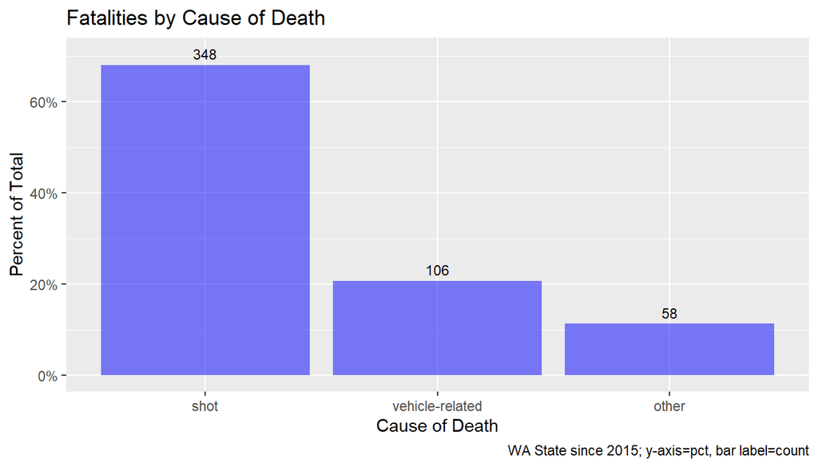

```r
homicides %>%
  mutate(
    cod_3 = factor(
      case_when(
        cod == "Gunshot" ~ "shot",
        grepl("Vehicle|Motorcycle", cod) ~ "vehicle-related",
        .default =  "other"),
      levels = c("shot", "vehicle-related", "other")),
    cod_3 =  forcats::fct_infreq(cod_3),
    cod_3 = fct_relevel(cod_3, "Unknown",
                        after = Inf)
  ) %>%

  count(cod_3) %>%
  mutate(perc = n / nrow(homicides)) %>%

  ggplot(aes(x=cod_3,
             y = perc,
             label = n)) +
  geom_text(aes(y = perc), size = 3, nudge_y = .025) +
  geom_bar(stat="identity", fill="blue", alpha=.5) +
  labs(title = "Fatalities by Cause of Death",
       caption = paste0("WA State since ",
                        params$from,
                        "; y-axis=pct, bar label=count")) +

  scale_y_continuous(labels = scales::percent_format(acc=1)) +

  xlab("Cause of Death") +
  ylab("Percent of Total")
```

### Table (Detailed COD)

```r
tab <- homicides %>%
  mutate(cod =  forcats::fct_infreq(cod),
         cod = fct_relevel(cod, "Unknown",
                             after = Inf)
  )%>%
  group_by(cod) %>%
  summarize(Number = n(),
            Percent = round(100*Number/nrow(homicides), 1)
  ) %>%
  adorn_totals("row")
tab %>%
  kable(caption = "Breakdown by Cause of Death",
        col.names = c("Cause of Death", "Number", "Percent")) %>%
  kable_styling(bootstrap_options = c("striped","hover")) %>%
  row_spec(which(tab$cod=="Total"), bold = T)  %>%
  add_footnote(label = "Percents may not sum to 100 due to rounding",
               notation = "symbol")
```

Breakdown by Cause of Death

| Cause of Death | Number | Percent |
| --- | --- | --- |
| Gunshot | 348 | 68.0 |
| Vehicle | 106 | 20.7 |
| Multiple types of force | 17 | 3.3 |
| Asphyxiated/Restrained | 11 | 2.1 |
| Drowned | 10 | 2.0 |
| Taser | 8 | 1.6 |
| Medical emergency | 3 | 0.6 |
| Burned/Smoke inhalation | 2 | 0.4 |
| Jumped to death | 2 | 0.4 |
| Ketamine | 2 | 0.4 |
| Beaten | 1 | 0.2 |
| Drug overdose | 1 | 0.2 |
| Knife | 1 | 0.2 |
| Total | 512 | 100.1 |

* Percents may not sum to 100 due to rounding

## Alleged weapon

The source of this information is typically the initial press release or report to the media from the involved law enforcement agency; it is not always possible to get independent verification. So it should be interpreted as the *alleged* weapon status of the person who was killed.

### Plot

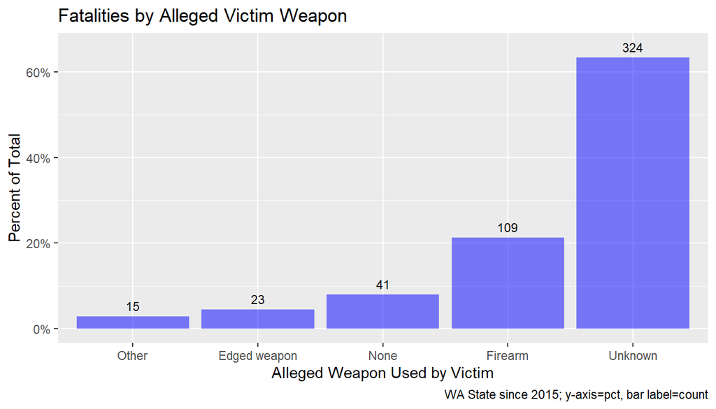

```r
homicides %>%
  count(weapon) %>%
  mutate(perc = n / nrow(homicides)) %>%

  ggplot(aes(reorder(weapon, perc),
             y = perc,
             label = n)) +
  geom_text(aes(y = perc), size = 3, nudge_y = .025) +
  geom_bar(stat="identity", fill="blue", alpha=.5) +
  labs(title = "Fatalities by Alleged Victim Weapon",
       caption = paste0("WA State since ",
                        params$from,
                        "; y-axis=pct, bar label=count")) +

  scale_y_continuous(labels = scales::percent_format(acc=1)) +

  xlab("Alleged Weapon Used by Victim") +
  ylab("Percent of Total")
```

## Video

This information comes from the MPV dataset, *so is not available for the data from other sources.* These additional cases are listed as “Unknown” below.

```r
tab <- homicides %>%
  mutate(
    video = case_when(
      is.na(footage) ~ "Unknown",
      .default =  footage),
    video = forcats::fct_infreq(video),
    video = fct_relevel(video, "Unknown",
                        after = Inf)) %>%
  group_by(video) %>%
  summarize(Number = n(),
            Percent = round(100*Number/nrow(homicides), 1)
  ) %>%
  adorn_totals("row")

tab %>%
  kable(caption = "Breakdown by video availability",
        col.names = c("Video", "Number", "Percent")) %>%
  kable_styling(bootstrap_options = c("striped","hover")) %>%
  row_spec(which(tab$video=="Unknown"), italic = T)  %>%
  row_spec(which(tab$video=="Total"), bold = T)  %>%
  add_footnote(label = "Percents may not sum to 100 due to rounding",
               notation = "symbol")
```

Breakdown by video availability

| Video | Number | Percent |
| --- | --- | --- |
| None | 148 | 28.9 |
| Bodycam | 95 | 18.6 |
| Surveillance | 13 | 2.5 |
| Bystander | 5 | 1.0 |
| Dashcam | 5 | 1.0 |
| Multiple footage types | 1 | 0.2 |
| Other | 1 | 0.2 |
| Unknown | 244 | 47.7 |
| Total | 512 | 100.1 |

* Percents may not sum to 100 due to rounding

## County

Washington State has 39 Counties. Since 2015 there have been people killed by police in 29 of them.

### Plot (top 5)

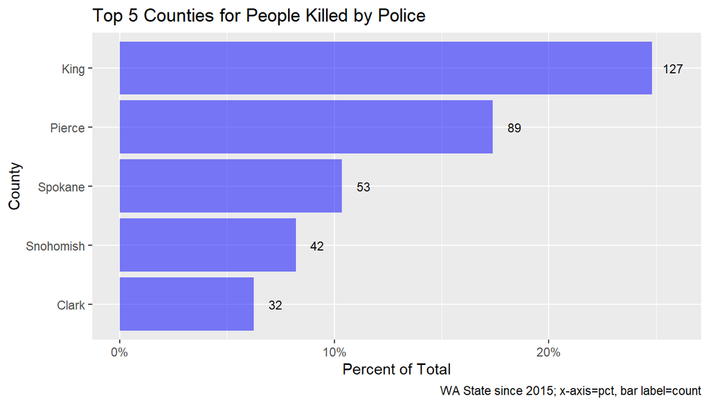

```r
tab <- homicides %>%
  group_by(county) %>%
  summarize(n = n(),
            perc = n / nrow(homicides)) %>%
  arrange(desc(n))

tab[1:5,] %>%

  ggplot(aes(reorder(county, perc),
             y = perc,
             label = n)) +
  geom_text(aes(y = perc), size = 3, nudge_y = .01) +
  geom_bar(stat="identity", fill="blue", alpha=.5) +

  labs(title = "Top 5 Counties for People Killed by Police",
       caption = paste0("WA State since ",
                        params$from,
                        "; x-axis=pct, bar label=count")) +
  xlab("County") +
  ylab("Percent of Total") +

  scale_y_continuous(labels = scales::percent_format(acc=1)) +

  coord_flip()
```

### Plot (top 5 after 2018)

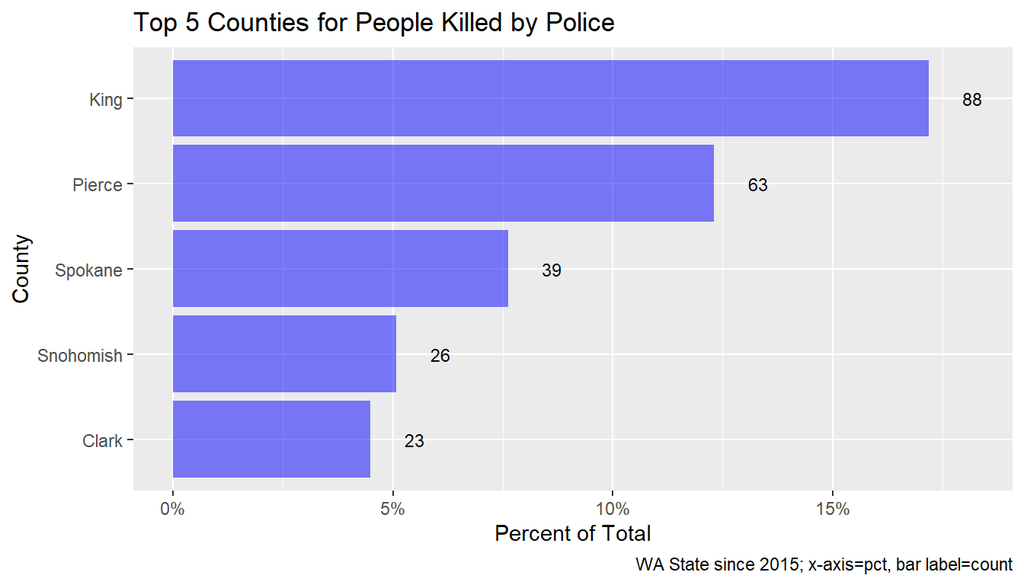

```r
tab <- homicides %>% filter(year > 2018) %>%

  group_by(county) %>%
  summarize(n = n(),
            perc = n / nrow(homicides)) %>%
  arrange(desc(n))

tab[1:5,] %>%

  ggplot(aes(reorder(county, perc),
             y = perc,
             label = n)) +
  geom_text(aes(y = perc), size = 3, nudge_y = .01) +
  geom_bar(stat="identity", fill="blue", alpha=.5) +

  labs(title = "Top 5 Counties for People Killed by Police",
       caption = paste0("WA State since ",
                        params$from,
                        "; x-axis=pct, bar label=count")) +
  xlab("County") +
  ylab("Percent of Total") +

  scale_y_continuous(labels = scales::percent_format(acc=1)) +

  coord_flip()
```

### Plot (all)

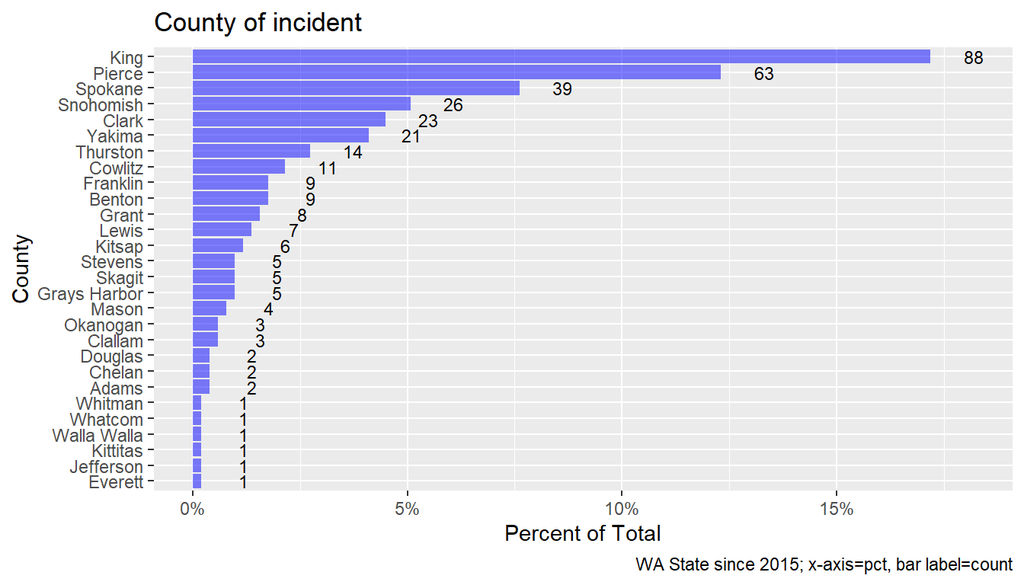

```r
tab %>%

  ggplot(aes(reorder(county, perc),
             y = perc,
             label = reorder(n, perc))) +
  geom_text(aes(y = perc), size = 3, nudge_y = .01) +
  geom_bar(stat="identity", fill="blue", alpha=.5) +

  labs(title = "County of incident",
       caption = paste0("WA State since ",
                        params$from,
                        "; x-axis=pct, bar label=count")) +
  xlab("County") +
  ylab("Percent of Total") +

  scale_y_continuous(labels = scales::percent_format(acc=1)) +

  coord_flip()
```

### Table

```r
tab %>%
  mutate(Percent = round(100*perc, 1)) %>%
  select(-perc) %>%
  DT::datatable(rownames = F,
                caption = "Fatalities since 2015 by county")
```

| county | n | Percent |
| --- | --- | --- |
| King | 88 | 17.2 |
| Pierce | 63 | 12.3 |
| Spokane | 39 | 7.6 |
| Snohomish | 26 | 5.1 |
| Clark | 23 | 4.5 |
| Yakima | 21 | 4.1 |
| Thurston | 14 | 2.7 |
| Cowlitz | 11 | 2.1 |
| Benton | 9 | 1.8 |
| Franklin | 9 | 1.8 |

[output cut: 18 more lines]

## Agency involved

There are more than 100 agencies that have been responsible for at least one fatality. Including all agencies on a single plot would make it impossible to read the text. So we plot 2 subsets:

The complete list of agencies is presented in the table.

- The table includes all agencies, all fatalities, and identifies the full list of agencies when there is more than one involved in the incident(s).

### Plot (top 10)

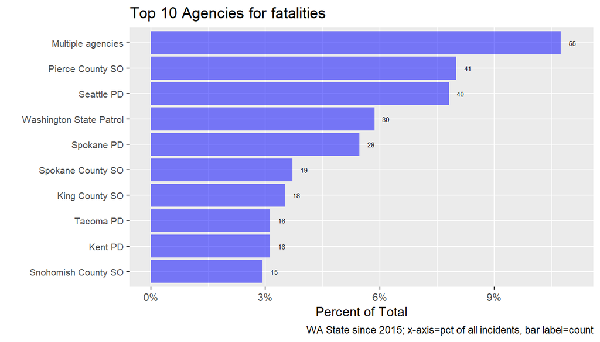

```r
tab <- homicides %>%
  mutate(agencyR = ifelse(grepl(",", agency), "Multiple agencies", agency),
         agencyR = sub("Police Department", "PD", agencyR),
         agencyR = sub("Sheriff's Office", "SO", agencyR),
         ) %>%
  group_by(agencyR) %>%
  summarize(n = n(),
            perc = n / nrow(homicides)) %>%
  arrange(desc(n))


tab[1:10,] %>%

  ggplot(aes(reorder(agencyR, perc),
             y = perc,
             label = n)) +
  geom_text(aes(y = perc), size = 2, nudge_y = .003) +
  geom_bar(stat="identity", fill="blue", alpha=.5) +

  labs(title = "Top 10 Agencies for fatalities",
       caption = paste0("WA State since ",
                        params$from,
                        "; x-axis=pct of all incidents, bar label=count")) +
  xlab("") +
  ylab("Percent of Total") +

  # this works with the flipped axis id
  theme(axis.text.y = element_text(size=8)) +

  scale_y_continuous(labels = scales::percent_format(acc=1)) +

  coord_flip()
```

### Plot (top 10 after 2018)

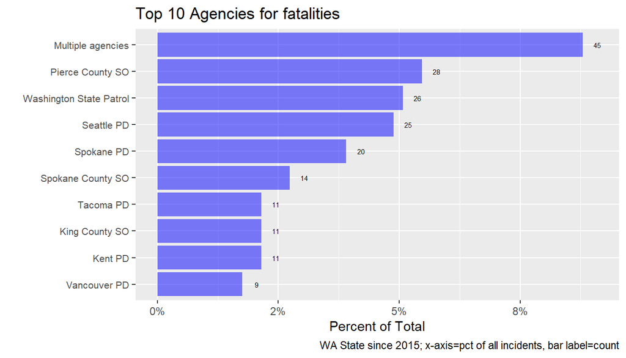

```r
tab <- homicides %>% filter (year > 2018) %>%

  mutate(agencyR = ifelse(grepl(",", agency), "Multiple agencies", agency),
         agencyR = sub("Police Department", "PD", agencyR),
         agencyR = sub("Sheriff's Office", "SO", agencyR),
         ) %>%
  group_by(agencyR) %>%
  summarize(n = n(),
            perc = n / nrow(homicides)) %>%
  arrange(desc(n))


tab[1:10,] %>%

  ggplot(aes(reorder(agencyR, perc),
             y = perc,
             label = n)) +
  geom_text(aes(y = perc), size = 2, nudge_y = .003) +
  geom_bar(stat="identity", fill="blue", alpha=.5) +

  labs(title = "Top 10 Agencies for fatalities",
       caption = paste0("WA State since ",
                        params$from,
                        "; x-axis=pct of all incidents, bar label=count")) +
  xlab("") +
  ylab("Percent of Total") +

  # this works with the flipped axis id
  theme(axis.text.y = element_text(size=8)) +

  scale_y_continuous(labels = scales::percent_format(acc=1)) +

  coord_flip()
```

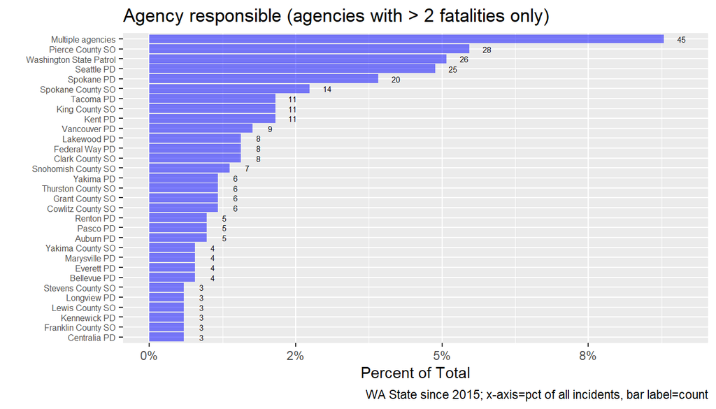

```r
tab %>%  filter(n > 2)  %>%

  ggplot(aes(reorder(agencyR, perc),
             y = perc,
             label = n)) +
  geom_text(aes(y = perc), size = 2, nudge_y = .003) +
  geom_bar(stat="identity", fill="blue", alpha=.5) +

  labs(title = "Agency responsible (agencies with > 2 fatalities only)",
       caption = paste0("WA State since ",
                        params$from,
                        "; x-axis=pct of all incidents, bar label=count")) +
  xlab("") +
  ylab("Percent of Total") +

  # this works with the flipped axis id
  theme(axis.text.y = element_text(size=6)) +

  scale_y_continuous(labels = scales::percent_format(acc=1)) +

  coord_flip()
```

### Table

```r
homicides %>%
  group_by(agency) %>%
  summarize(Number = n(),
            Percent = round(100*Number/nrow(homicides), 1)
  ) %>%
  DT::datatable(rownames = F,
                caption = "Fatalities by Agency of Involved Officer",
                filter = 'top',
                escape = FALSE,
                extensions = 'Buttons',
                options = list(
                  dom = 'Bfrtip',
                  buttons = c('copy', 'csv', 'excel', 'pdf', 'print')) )
```

| agency | Number | Percent |
| --- | --- | --- |
| Aberdeen Police Department | 1 | 0.2 |
| Airway Heights Police Department, Spokane County Sheriff's Office | 1 | 0.2 |
| Algona Police Department | 1 | 0.2 |
| Auburn Police Department | 8 | 1.6 |
| Bainbridge Island Police Department | 1 | 0.2 |
| Bellevue Police Department | 4 | 0.8 |
| Bellingham Police Department | 2 | 0.4 |
| Benton County Sheriff's Office | 3 | 0.6 |
| Black Diamond Police Department | 1 | 0.2 |
| Bothell Police Department | 2 | 0.4 |

[output cut: 140 more lines]

## Legislative Districts

This information is obtained by geocoding the latitude and longitude data on the [geocodio](https://www.geocod.io/) platform.

Washington State has 49 legislative districts. Since 2015 there have been people killed by police in 43 of them.

Given the number of districts involved, we plot the top 10 for legibility .

The table includes all districts and all incidents.

### Plot (top 10)

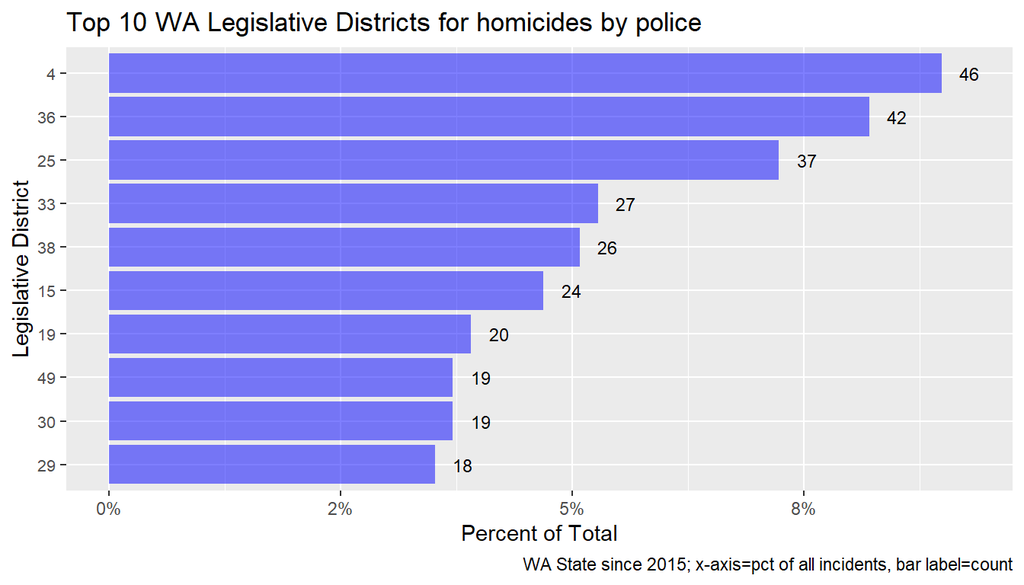

```r
tab <- homicides %>%
  group_by(st_district) %>%
  summarize(n = n(),
            perc = n / nrow(homicides)) %>%
  arrange(desc(n))

tab[1:10,] %>%

  ggplot(aes(reorder(st_district, perc),
             y = perc,
             label = n)) +
  geom_text(aes(y = perc), size = 3, nudge_y = .003) +
  geom_bar(stat="identity", fill="blue", alpha=.5) +

  labs(title = "Top 10 WA Legislative Districts for homicides by police",
       caption = paste0("WA State since ",
                        params$from,
                        "; x-axis=pct of all incidents, bar label=count")) +
  xlab("Legislative District") +
  ylab("Percent of Total") +

  # this works with the flipped axis id
  theme(axis.text.y = element_text(size=8)) +

  scale_y_continuous(labels = scales::percent_format(acc=1)) +

  coord_flip()
```

### Table

```r
homicides %>%
  group_by(st_district) %>%
  summarize(Number = n(),
            Percent = round(100*Number/nrow(homicides), 1)
  ) %>%
  DT::datatable(rownames = F,
                caption = "Breakdown of Fatalities by WA Legislative District",
                filter = 'top',
                escape = FALSE,
                extensions = 'Buttons',
                options = list(
                  dom = 'Bfrtip',
                  buttons = c('copy', 'csv', 'excel', 'pdf', 'print')) )
```

| st_district | Number | Percent |
| --- | --- | --- |
| 1 | 2 | 0.4 |
| 2 | 9 | 1.8 |
| 4 | 46 | 9 |
| 5 | 4 | 0.8 |
| 6 | 4 | 0.8 |
| 7 | 13 | 2.5 |
| 8 | 8 | 1.6 |
| 9 | 5 | 1 |
| 10 | 4 | 0.8 |
| 11 | 9 | 1.8 |

[output cut: 33 more lines]

# Trend over time

There are two sets of plots here. The first focuses on the monthly totals, and how they have changed over time. The second focuses on the cumulative totals as the year progresses, and how this has changed over time.

```r
# index restricted to first/last complete month
thisyr <- as.character(max(index$year))
prevyrs1 <- paste0(min(index$year), "-", max(index$year)-1)
prevyrs2 <- paste0(min(index$year), "-", last_complete_yr-1)

# left_join to index imposes same restriction
df_by_month <- homicides %>%
  group_by(year, month) %>%
  summarize(count = n()) %>%
  left_join(index, ., by = c("year", "mon"="month")) %>%
  mutate(count = tidyr::replace_na(count, 0),
         mo = match(mon, month.abb),
         mon = factor(mon, levels = month.abb),
         this.yr = factor(ifelse(year==max(year),
                                 thisyr,
                                 prevyrs1),
                          levels = c(prevyrs1, thisyr)),
         last.compl.yr = factor(ifelse(year==last_complete_yr,
                                 as.character(last_complete_yr),
                                 prevyrs2),
                          levels = c(prevyrs2, as.character(last_complete_yr))))

yrs <- as.numeric(lubridate::ymd(
  paste0(seq(min(index$year), max(index$year), 1),
         "-", start_mo, "-01")))
```

## Monthly totals

### Trend

- The points show the monthly totals, the grey line shows the smoothed average trend in monthly fatalities over time, and the grey shaded ribbon shows the 95% confidence interval around the trend line.
- We only plot months once the data are complete, so the plot will lag 1-2 months behind the current date.
- This is an interactive plot: You can hover over points to get the exact values for the number of cases for that month and year.

```r
# we will only plot after current month has finished

p <- ggplot(df_by_month, aes(x = index.date,
                     y = count))  +
  geom_point(size=1.5, shape=21, stroke=0.25,
             aes(fill = factor(year),
                 text = paste0(mon, ": ", count))) +
  #geom_smooth(span = params$smooth_span, col="grey")  +
   geom_smooth(span = params$smooth_span-0.2, col="grey")  +


  # year boundaries
  geom_vline(xintercept = yrs, col="white", alpha=.5) +

  geom_hline(yintercept = 0, col="grey") +

  labs(title = paste("Monthly fatalities:",
                     month.abb[start_mo], start_yr, " - ",
                     month.abb[last_complete_mo], max(index$year)),
       x = "Month/Year",
       y = "Number",
       caption = paste("WA since", params$startyr),
       fill = "Year") +

  ylim(c(-2, NA)) + # min needs to be < smoother lower se

  scale_x_continuous(
    breaks = df_by_month$index.date[seq(1, nrow(df_by_month), 12)],
    label = df_by_month$year[seq(1, nrow(df_by_month), 12)]
    )  +

  scale_y_continuous(breaks = seq(0, 12, by=2)) +

  theme(axis.text.x = element_text(size = rel(0.8))) +
  theme(panel.grid.major = element_blank(),
        panel.grid.minor = element_blank())

ggplotly(p, tooltip = "text") %>%
  style(hoverinfo = "y", traces = 9) # use plotly_json(p) to verify
```

[interactive chart not shown]

### With key dates

This plot highlights key dates for legislation and legal actions related to police practices and accountability.

- The $\color{blue}{\textsf{blue lines}}$ are legislative/regulatory actions (940 passes, 940 WACs, and effective dates of legislation from 2021 forward). Solid lines are reform policies aimed at reducing police violence; dashed lines are partial rollbacks of these reforms.
- The $\color{red}{\textsf{red lines}}$ are legal actions (Ellis investigation taken over by AGO, ex-Officer Nelson charged in Jesse Sarey case, Officers Burbank Collins and Rankine charged in Ellis case). Solid lines are actions taken to hold officers accountable; dashed lines are acquittals and exonerations.
- This is an interactive plot: You can hover over points to get the number of cases for that month, and hovering at the top or bottom of the vertical lines will identify the action.

```r
p <- ggplot(df_by_month,
            aes(x = index.date, y = count))  +
  geom_point(size=1.5, shape=21, stroke=0.25,
             aes(text = paste0(mon, ": ", count))) +
  geom_smooth(span = params$smooth_span-0.2, col="grey")  +

  # year boundaries
  geom_vline(xintercept = yrs, col="white", alpha=.5) +


  # reline y-axis in case yr[1] = start_date
  geom_vline(aes(xintercept = as.numeric(start_date),
                 text = ""),
             col="grey", alpha=.8) +

  # key dates for prosecution
  geom_vline(aes(xintercept = as.numeric(date.ellis.ago),
                 text = "Ellis case taken over by AGO"),
             col="red", alpha=.8) +
  geom_vline(aes(xintercept = as.numeric(date.sarey.charged),
                 text = "Sarey case officer charged"),
             col="red", alpha=.8) +
  geom_vline(aes(xintercept = as.numeric(date.ellis.charged),
                 text = "Ellis case officers charged"),
             col="red", alpha=.8) +
  geom_vline(aes(xintercept = as.numeric(date.ellis.acquit),
                 text = "Ellis case officers acquitted"),
             col="red", lty=2, alpha=.8) +
    geom_vline(aes(xintercept = as.numeric(date.nelson.convicted),
                 text = "ex-Officer Nelson convicted of murder"),
             col="red", alpha=.8) +


  # key dates for legislation
  geom_vline(aes(xintercept = as.numeric(date.940.pass),
                 text = "940 passes"),
             col="blue", alpha=.8) +
  geom_vline(aes(xintercept = as.numeric(date.940.WAC),
                 text = "940 WACs take effect"),
             col="blue", alpha=.8) +
  geom_vline(aes(xintercept = as.numeric(date.2021.law),
                 text = "2021 laws"),
             col="blue", alpha=.8) +
  geom_vline(aes(xintercept = as.numeric(date.2022.law),
                 text = "2022 laws"),
             col="blue", lty=2, alpha=.8) +
  geom_vline(aes(xintercept = as.numeric(date.2023.law),
                 text = "2023 laws"),
             col="blue", lty=2, alpha=.8) +
    geom_vline(aes(xintercept = as.numeric(date.2024.rollback),
                 text = "2024 pursuit rollback"),
             col="blue", lty=2, alpha=.8) +

  # zero axis
  geom_hline(yintercept = 0, col="grey") +

  labs(title = paste("Monthly fatalities with key dates:",
                     month.abb[start_mo], start_yr, " - ",
                     month.abb[last_complete_mo], max(index$year)),
       x = "Month/Year",
       y = "Number",
       caption = paste("WA since", params$startyr),
       fill = "Year") +

  scale_x_continuous(
    breaks = df_by_month$index.date[seq(1, nrow(df_by_month), 12)],
    label = df_by_month$year[seq(1, nrow(df_by_month), 12)]
    )  +

  scale_y_continuous(breaks = seq(0, 12, by=2)) +

  theme(axis.text.x = element_text(size = rel(0.8))) +
  theme(panel.grid.major = element_blank(),
        panel.grid.minor = element_blank())

ggplotly(p, tooltip = "text") %>%
  style(hoverinfo = "y", traces = 2)
```

[interactive chart not shown]

### This year vs. previous years

```r
# we will only plot after current month has finished

# make sure the factor levels match
this.yr.color = c("lightsteelblue", "black")
names(this.yr.color) <- levels(df_by_month$this.yr)
this.yr.alpha = c(0.5, 1)
names(this.yr.alpha) <- levels(df_by_month$this.yr)

p <- ggplot(data = df_by_month,
            aes(x = mo, y = count)) +

  geom_jitter(aes(col = this.yr,
                  alpha = this.yr,
                  text = mon.yr),
              width = 0, height = .1) +
  scale_color_manual(name="Year",
                     values=this.yr.color) +
  scale_alpha_manual(values=this.yr.alpha) +
  guides(alpha = "none") +

  geom_smooth(data = df_by_month %>% filter(year != max(year)),
              color = "lightsteelblue") +
  geom_smooth(data = df_by_month %>% filter(year == max(year)), se=F,
              color = "black") +

  scale_x_continuous(breaks = seq(1,12,1),
                     label = month.abb) +

  labs(title = paste0("WA since ", params$startyr,
                     ":  Monthly totals with moving average"),
       caption = paste("WA since", params$startyr)) +
  xlab("Month") +
  ylab("Number of people killed")


ggplotly(p, tooltip = "text") %>%
  style(hoverinfo = "y", traces = 3)
```

[interactive chart not shown]

### Last complete year vs. previous years

- The points show the monthly totals for each year. They are color coded to highlight the current year.
- The blue line shows the moving average for the monthly fatality rate for the 2015-2024 period, and the grey shaded ribbon shows the 95% confidence band around that average.
- The black line shows the moving average for the monthly fatality rate for 2025, the last complete year. *When this line lies outside the grey ribbon for the blue line, this suggests the difference between this year and previous years is larger than normal variation would predict.*
- This is an interactive plot: You can hover over points to get the month and year for each point.

```r
# make sure the factor levels match
last.compl.yr.color = c("lightsteelblue", "black")
names(last.compl.yr.color) <- levels(df_by_month$last.compl.yr)
last.compl.yr.alpha = c(0.5, 1)
names(last.compl.yr.alpha) <- levels(df_by_month$last.compl.yr)

p <- ggplot(data = df_by_month %>% filter(year <= last_complete_yr),
            aes(x = mo, y = count)) +

  geom_jitter(aes(col = last.compl.yr,
                  alpha = last.compl.yr,
                  text = mon.yr),
              width = 0, height = .1) +
  scale_color_manual(name="Year",
                     values=last.compl.yr.color) +
  scale_alpha_manual(values=last.compl.yr.alpha) +
  guides(alpha = "none") +

  geom_smooth(data = df_by_month %>% filter(year != last_complete_yr),
              color = "lightsteelblue") +
  geom_smooth(data = df_by_month %>% filter(year == last_complete_yr), se=F,
              color = "black") +

  scale_x_continuous(breaks = seq(1,12,1),
                     label = month.abb) +

  labs(title = paste0("WA since ", params$startyr,
                     ":  Monthly totals with moving average"),
       caption = paste("WA since", params$startyr)) +
  xlab("Month") +
  ylab("Number of people killed")


ggplotly(p, tooltip = "text")  %>%
  style(hoverinfo = "y", traces = 3) # use plotly_json(p) to verify
```

[interactive chart not shown]

## Annual totals

### Cumulative by month

- The lines show the cumulative total fatalities by month as the year progresses, for each year.
- We only plot months once the data are complete, so the plot will lag 1-2 months behind the current date.

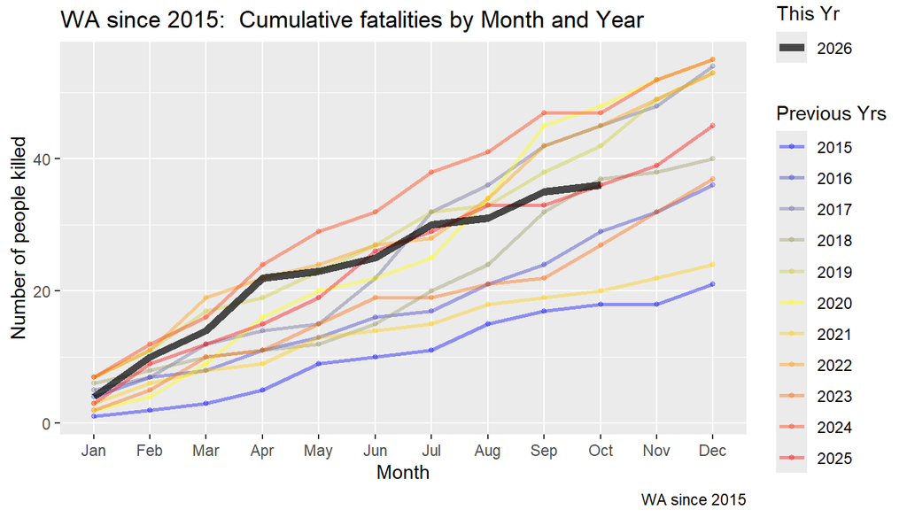

```r
# plotly doesn't handle the multiple legend properly so we don't use it here

# set up color palette for previous years:
n.yrs <- max(index$year) - params$startyr # num yrs excl this yr
paletteFunc <- colorRampPalette(c('blue', 'yellow', 'red'))
my.colors <- paletteFunc(n.yrs)


df <- df_by_month %>%
  group_by(year) %>%
  mutate(cumulative = cumsum(count),
         mon = factor(mon, levels=month.abb))

# Plot prev yrs separately and specify 2 aes (color, ltyp) to get 2 legends

ggplot(data= df %>% filter(year != max(df$year)),
       aes(x = mon,
           y = cumulative,
           color = factor(year),
           group = year)) +

  geom_line(size = 1, alpha = .4) +
  geom_point(aes(text = paste('Total =', cumulative, '<br>',
                              mon, '<br>', year)),
                 size=1, alpha = .3) +
  scale_color_manual(values = my.colors) +

  geom_line(data = df %>% filter(year == max(df$year)),
            aes(x = mon,
                y = cumulative,
                linetype = factor(year),
                text = paste('Total =', cumulative, '<br>',
                             mon, '<br>', year)),
            color = "black", size = 2, alpha = 0.7) +
  scale_linetype_manual(name = "This Yr", values = c("solid")) +

  labs(title = paste0("WA since ", params$startyr,
                     ":  Cumulative fatalities by Month and Year"),
       x = "Month",
       y = "Number of people killed",
       caption = paste("WA since", params$startyr),
       color = "Previous Yrs") +

  guides(linetype = guide_legend(order = 1),
         color = guide_legend(order = 2)
         )
```

```r
#ggplotly(p, tooltip = "text")
```

### By year

#### Calendar year

```r
graphdf.calyr <- homicides %>%
  filter(year >= params$startyr) %>%
  group_by(Year = year) %>%
  summarize(Num = n())

p <- ggplot(graphdf.calyr,
       aes(x = Year, y = Num,
           fill = Num,
           text = Num)) +

  geom_bar(stat = "identity", color="gray20") +

  scale_fill_gradient(low = "seashell", high = "firebrick",
                      guide = "none") +

  scale_x_continuous(breaks = unique(graphdf.calyr$Year)) +

  annotate("text",
           x = graphdf.calyr$Year[nrow(graphdf.calyr)],
           y = graphdf.calyr$Num[nrow(graphdf.calyr)] + 1,
           size = 3, label = "YTD") +

  labs(title = "People killed by police in WA by Year",
       x = "Calendar year",
       y = "Number killed")

ggplotly(p, tooltip = "text")
```

[interactive chart not shown]

#### Legislative year

We start with the first complete legislative year.

```r
graphdf.legyr <- homicides %>%
  filter(date > as.Date(params$startlegyr)) %>%
  group_by(leg.year) %>%
  summarize(Num = n())

p <- ggplot(graphdf.legyr,
       aes(x = leg.year, y = Num,
           fill = Num,
           text = Num)) +

  geom_bar(stat = "identity", color="gray20") +

  scale_fill_gradient(low = "seashell", high = "firebrick",
                      guide = "none") +

  scale_x_discrete(labels = function(x)
    stringr::str_wrap(graphdf.legyr$leg.year, width = 8)) +

  theme(axis.text.x = element_text(size = 5)) +

  annotate("text",
           x = graphdf.legyr$leg.year[nrow(graphdf.legyr)],
           y = graphdf.legyr$Num[nrow(graphdf.legyr)] + 1,
           size = 3, label = "YTD") +

  labs(title = "People killed by police in WA by Legislative Year",
       x = "Legislative year",
       y = "Number killed")

ggplotly(p, tooltip = "text")
```

[interactive chart not shown]

### By cause of death

Here we plot the cumulative totals each year, broken down to show the two leading causes of death.

- The bars represent totals for each year, divided by cause of death: gunshot, vehicle pursuit and all other causes. A case is classified as a vehicle pursuit death if the cause of death was vehicular accident during an active or recently terminated vehicle pursuit.
- Note that the current year only reflects cases for the year to date (November 20 2026), so is not strictly comparable with the previous years.
- This is an interactive plot: You can hover over bar segments to get the exact values for that cause of death in that year.

#### Calendar year

```r
graphdf.calyr <-  homicides %>%
  filter(year >= params$startyr) %>%
  mutate(
    cod_3 = factor(
      case_when(
        cod == "Gunshot" ~ "Shot",
        grepl("Active|Terminated", pursuit.type) ~ "Vehicle pursuit",
        .default =  "Other"),
      levels = c("Shot", "Vehicle pursuit", "Other")),
    year = as.character(year)) %>%
  group_by(year, cod_3) %>%
  summarize(n = n()) %>%
  mutate(percent = round(100*n / sum(n), 1))

p <- ggplot(graphdf.calyr,
            aes(x = year, y = n,
             fill = cod_3,
             text = paste0("N=", n,
                           " (", round(percent),"%)"))
         ) +

  geom_bar(stat="identity", alpha=.5, color = "grey",
           position = position_stack(reverse=T)) +

  annotate("text",
           x = graphdf.calyr$year[nrow(graphdf.calyr)],
           y = sum(graphdf.calyr$n[(nrow(graphdf.calyr)-2):nrow(graphdf.calyr)]) + 1,
           size = 3, label = "YTD") +

  scale_fill_manual(values = c("cadetblue","darkorange3", "goldenrod")) +

  labs(title = paste0("Fatalities by Cause of Death and Year"),
       caption = paste("WA since", params$startyr),
       x = "Year",
       y = "Number",
       fill = "Cause of\nDeath")

ggplotly(p, tooltip = "text")
```

[interactive chart not shown]

#### Legislative year

We start with the first complete legislative year.

```r
graphdf.legyr <-  homicides %>%
  filter(date > as.Date(params$startlegyr)) %>%
  mutate(
    cod_3 = factor(
      case_when(
        cod == "Gunshot" ~ "Shot",
        grepl("Active|Terminated", pursuit.type) ~ "Vehicle pursuit",
        .default =  "Other"),
      levels = c("Shot", "Vehicle pursuit", "Other")),
    year = as.character(year)) %>%
  group_by(leg.year, cod_3) %>%
  summarize(n = n()) %>%
  mutate(percent = round(100*n / sum(n), 1))

p <- ggplot(graphdf.legyr,
            aes(x = leg.year, y = n,
                fill = cod_3,
                text = paste0("N=", n,
                              " (", round(percent),"%)"))
            ) +

  geom_bar(stat="identity", alpha=.5, color = "grey",
           position = position_stack(reverse=T)) +

  annotate("text",
           x = graphdf.legyr$leg.year[nrow(graphdf.legyr)],
           y = sum(graphdf.legyr$n[(nrow(graphdf.legyr)-2):nrow(graphdf.legyr)]) + 1,
           size = 3, label = "YTD") +

  scale_fill_manual(values = c("cadetblue","darkorange3", "goldenrod")) +

  scale_x_discrete(labels = function(x)
    stringr::str_wrap(unique(graphdf.legyr$leg.year), width = 8)) +

  theme(axis.text.x = element_text(size = 5)) +

  labs(title = paste0("Fatalities by Cause of Death and Legislative Year"),
       caption = paste("WA since", params$startyr),
       x = "Legislative Year",
       y = "Number",
       fill = "Cause of\nDeath")

ggplotly(p, tooltip = "text")
```

[interactive chart not shown]

# WA vs. other states

Here we report the annual totals up through the last complete year – 2025 – with data from the MPV project only, since MPV provides the only consistent national data series. This limits incidents to those meeting the MPV inclusion criteria: it includes people killed by police with firearms, tasers, asphyxiation and other uses of force, but excludes most pursuit related fatalities.

## Compared to all other states

### Population adjusted rate

The number of people killed is represented here as a population-adjusted rate per million residents, which makes it possible to compare states with different sized populations. The raw numbers are given on the next tab.

Keep in mind that this uses the MPV data, so it excludes most people killed in police pursuits.

```r
p <- ggplot(state.rates %>% filter(grepl("Washington|Other", state)),
       aes(x=factor(year), y=rate,
           group=state, fill=state,
           text =paste("rate: ", round(rate, 1)))) +
  geom_col(alpha = 0.7) + #coord_flip() +
  facet_wrap(~state) +

  theme(axis.text.x = element_text(size = 6),
        axis.text.y = element_text(size = 8)) +

  labs(title = "Rate of persons killed by police: MPV data",
       x="Year", y="Rate per million residents")

ggplotly(p, tooltip = "text")
```

[interactive chart not shown]

### Number killed and annual percent change

```r
kable(mpv_tab,
      caption = "Persons killed by police: MPV data",
      col.names = c("Year", rep(c("All other states", "WA"), 2)),
      digits = c(0,0,0,1,1),
      align = c("l",rep("r", 4))) %>%

  kable_styling(bootstrap_options = c("striped","hover"),
                full_width = F) %>%
  add_header_above(c("", "Number" = 2, "Percent Change" = 2 ))
```

Persons killed by police: MPV data

| Year | Number All other states | Number WA | Percent Change All other states | Percent Change WA |
| --- | --- | --- | --- | --- |
| 2015 | 1082 | 19 | NA | NA |
| 2016 | 1038 | 27 | -4.07% | 42.1% |
| 2017 | 1064 | 42 | 2.50% | 55.6% |
| 2018 | 1127 | 27 | 5.92% | -35.7% |
| 2019 | 1076 | 41 | -4.53% | 51.9% |
| 2020 | 1126 | 36 | 4.65% | -12.2% |
| 2021 | 1177 | 14 | 4.53% | -61.1% |
| 2022 | 1227 | 41 | 4.25% | 192.9% |
| 2023 | 1335 | 24 | 8.80% | -41.5% |
| 2024 | 1351 | 35 | 1.20% | 45.8% |
| 2025 | 1293 | 25 | -4.29% | -28.6% |

## State rankings 2025

Here we report the MPV data by state for the most recent complete year: 2025.

### Number killed

- States are ranked by the the number of persons killed in 2025.
- The bar for WA State is highlighted with a black border.
- These are interactive plots: You can hover over bars to get the exact values for the number of persons killed in 2025.

```r
p <- ggplot(data = states.all %>% filter(!grepl("United|Other", state)),
            aes(x=killed2025, y=reorder(state, killed2025),
                fill = killed2025,
                color = factor(ifelse(state=="Washington", 1, 0)),
                text=paste(state,
                           "total:", killed2025))) +

  geom_col() +

  scale_color_manual(values = c("grey", "black")) +
  scale_fill_gradient2(
    low = "blue",
    mid = "white",
    high = "red",
    midpoint = median(states.all$killed2025)) +
  #scale_x_continuous(labels = scales::percent) +

  theme(axis.text.y=element_text(size=rel(.7)), legend.position = "none") +
  labs(title = paste("State ranking: Number of persons killed by police in", last_complete_yr),
       x="Number killed",
       y="State")

ggplotly(p, tooltip = "text")
```

[interactive chart not shown]

### Population-adjusted rate

- States are ranked by the population adjusted rate of persons killws in 2025: the rate per million state residents.
- The bar for WA State is highlighted with a black border.
- These are interactive plots: You can hover over bars to get the exact values for the rate of persons killed in 2025.

```r
p <- ggplot(data = states.all %>% filter(!grepl("United|Other", state)),
            aes(x=ratekilled2025, y=reorder(state, ratekilled2025),
                fill = ratekilled2025,
                color = factor(ifelse(state=="Washington", 1, 0)),
                text=paste(state,
                           "total:", round(ratekilled2025, 1)))
            ) +

  geom_col() +

  scale_color_manual(values = c("grey", "black")) +
  scale_fill_gradient2(
    low = "blue",
    mid = "white",
    high = "red",
    midpoint = median(states.all$ratekilled2025)) +
  #scale_x_continuous(labels = scales::percent) +

  theme(axis.text.y=element_text(size=rel(.7)), legend.position = "none") +
  labs(title = paste("State ranking: Population adjusted rate of persons killed by police in", last_complete_yr),
       x="Rate per million residents",
       y="State")

ggplotly(p, tooltip = "text")
```

[interactive chart not shown]

```r
df <- states.all %>%
  filter(!grepl("United|Other", state)) %>%
  select(state, killed2023:killed2025) %>%
  mutate(pct.chg = killed2025/killed2023 -1)

p <- ggplot(data = df,
            aes(x=pct.chg, y=reorder(state, pct.chg),
                fill = pct.chg,
                color = factor(ifelse(state=="Washington", 1, 0)),
                text=paste0(state,
                           paste("<br>", "number killed in ", last_complete_yr, ": ", killed2025),
                           paste("<br>", "change from last year: ", scales::percent(pct.chg, acc = 1))))
            ) +

  geom_col() +

  scale_color_manual(values = c("grey", "black")) +
  scale_fill_gradient2(
    low = "blue",
    mid = "white",
    high = "red",
    midpoint = 0) +
  scale_x_continuous(labels = scales::percent) +

  theme(axis.text.y=element_text(size=rel(.7)), legend.position = "none") +
  labs(title = paste("State ranking: % change in number of persons killed by police",
                     last_complete_yr-1, "-", last_complete_yr),
       x="Percent change",
       y="State")

ggplotly(p, tooltip = "text")
```

[interactive chart not shown]

# Say their names

## Name known

Of the 512 persons killed by police, 488 of the victim’s names are known at this time. In the table below “WA-LD” refers to the Washington state legislative district.

NOTE: There are 2 tabs above, one for the names we do know, the other for the names we don’t yet know. Selecting a tab will display the associated table.

```r
homicides %>%
  mutate(date = as.Date(date)) %>%
  arrange(desc(date)) %>%
  #mutate(date = format(as.Date(date), format = "%m/%d/%Y")) %>% can't use format, sorting fails
  filter(name != "Unknown") %>%
  select(name, date, age=age, race, county, `WA-LD`=st_district,
         agency, link = url_click) %>%

  DT::datatable(rownames = F,
                caption = paste("The Names We Know:  as of", scrape_date),
                filter = 'top',
                escape = FALSE,
                extensions = 'Buttons',
                options = list(
                  dom = 'Bfrtip',
                  buttons = c('copy', 'csv', 'excel', 'pdf', 'print')) )
```

| name | date | age | race | county | WA-LD | agency | link |
| --- | --- | --- | --- | --- | --- | --- | --- |
| David Aaron Bauschman | 2026-11-15 | 54 | Unknown | Pierce | 29 | Lakewood Police Department, Pierce County Sheriffs Office, Washington State Patrol | https://komonews.com/news/local/pierce-county-judge-sets-1m-bail-for-20-year-old-accused-of-killing-man-in-dui-crash-spanway-i5-speeding-crime |
| Sonny Miranda Mitchell | 2026-11-05 | 47 | Unknown | King | 11 | Renton Police Department; Tukwila Police Department | https://www.seattleweekly.com/2026/11/09/man-fatally-shot-by-renton-police-identified/ |
| Ryan T Larsen | 2026-11-03 | 37 | Unknown | Spokane | 9 | Spokane County Sheriff's Office; SWAT | https://www.spokesman.com/stories/2026/nov/04/suspect-in-fatal-deputy-shooting-is-37-year-old-wi/ |
| Christopher H Derrick | 2026-10-21 | 47 | Unknown | Franklin | 14 | Richland Police Department | https://www.tri-cityherald.com/news/local/crime/article317720374.html |
| Gerald Brandon Colwell | 2026-09-27 | 49 | WEA | Pierce | 25 | Tacoma Police Department | https://www.kiro7.com/news/local/officer-involved-shooting-tacoma/EQXYC523SVBQRF5SWNZPLC6A3M/ |
| Keenan Charles Pearson | 2026-09-12 | 47 | BAA | King | 36 | Seattle Police Department | https://www.divestspd.com/p/seattle-police-kneeled-on-man-who |
| Michael James Sowards | 2026-09-10 | 21 | WEA | King | 30 | Federal Way Police Department | https://www.federalwaymirror.com/2026/09/14/man-21-fatally-shot-by-federal-way-police-identified/ |
| Joel B Malin | 2026-09-08 | 20 | WEA | Spokane | 4 | Spokane County Sheriff's Office | https://www.spokesman.com/stories/2026/sep/15/man-killed-by-deputy-at-evergreen-middle-school-ca/ |
| Jusstina Sabrina Murrietta | 2026-08-23 | 23 | AIAN | King | 30 | Washington State Patrol | https://www.king5.com/article/news/crime/bail-set-500k-for-driver-accused-in-deadly-crash-after-13-mile-pursuit/281-53a49452-e833-408e-a1ff-05c8f898f825 |
| David Castillo | 2026-07-31 | 43 | WEA | Spokane | 6 | Airway Heights Police Department, Spokane County Sheriff's Office | https://www.khq.com/news/independent-investigation-underway-following-law-enforcement-shooting-in-airway-heights/article_92a1fd51-f378-4350-94c1-4847c7a6af02.html |

[output cut: 478 more lines]

## Name Unknown

The remaining 24 of the victim’s names are not known at this time. In the table below “WA-LD” refers to the Washington state legislative district.

```r
homicides %>%
  mutate(date = as.Date(date)) %>%
  arrange(desc(date)) %>%
  filter(name == "Unknown") %>%
  select(name, date, age=age, race, county, `WA-LD`=st_district,
         agency, link = url_click) %>%
  arrange(desc(date)) %>%
  DT::datatable(rownames = F,
                caption = paste("The Names We Don't Know:  as of", scrape_date),
                filter = 'top',
                escape = FALSE,
                extensions = 'Buttons',
                options = list(
                  dom = 'Bfrtip',
                  buttons = c('copy', 'csv', 'excel', 'pdf', 'print')) )
```

| name | date | age | race | county | WA-LD | agency | link |
| --- | --- | --- | --- | --- | --- | --- | --- |
| Unknown | 2026-04-01 |  | Unknown | Snohomish | 21 | Snohomish County Sheriff's Office | https://www.king5.com/article/news/crime/suspect-killed-shooting-martha-lake/281-729e1d01-7cc5-465c-8e05-b8ea30671725 |
| Unknown | 2026-03-20 |  | Unknown | Snohomish | 38 | Everett Police Department | https://www.heraldnet.com/2026/03/20/one-man-died-after-an-officer-involved-shooting-in-everett/ |
| Unknown | 2025-11-16 | 42 | Unknown | Spokane | 4 | Spokane Tribal Police | https://www.spokesman.com/stories/2025/nov/18/man-presumed-to-have-drowned-after-running-from-sp/ |
| Unknown | 2025-08-23 | 45 | HL | Everett | 38 | Everett Police Department | https://www.fox13seattle.com/news/car-crashes-everett-wa-building |
| Unknown | 2025-05-10 | 19 | BAA | King | 36 | Washington State Patrol | https://www.youtube.com/watch?v=f0DcnWPFSsQ |
| Unknown | 2025-04-12 |  | Unknown | Kitsap | 26 | Bremerton Police Department | https://www.kitsapdailynews.com/news/1-dead-another-injured-in-single-car-accident-in-bremerton/ |
| Unknown | 2025-03-23 |  | Unknown | Stevens | 7 | Stevens County Sheriff's Office | https://www.spokesman.com/stories/2025/mar/24/stevens-county-deputies-kill-suspect-in-standoff-n/ |
| Unknown | 2025-02-13 | 43 | Unknown | Skagit | 10 | Washington State Patrol | https://www.skagitcounty.net/SMART/Documents/PressRelease/SMART%20Press%20Release%20-I-5%20021325.pdf |
| Unknown | 2025-02-01 | 16 | Unknown | King | 44 | Lake Forest Park Police Department | https://komonews.com/news/local/16-year-old-dies-in-bothell-crash-after-possible-police-pursuit-2-passengers-injured-fatal-deadly-investigation |
| Unknown | 2025-01-07 |  | Unknown | Snohomish | 38 | Marysville Police Department | https://www.seattletimes.com/seattle-news/law-justice/driver-dies-after-being-shot-by-police-crashing-into-marysville-costco/ |

[output cut: 14 more lines]

# Appendices

## Legislative history

Police accountability and reform has been an active topic in the Washington state legislature since 2018. Changes have been achieved via both citizen initiative and traditional bills.

One of the first major legislative reforms was Initiative 940. I-940 established de-escalation training requirements, independent investigations of all homicides by police and changed the criminal accountability standard from malice to reasonable officer. It passed with over 60% of the statewide vote in the 2018 November general election, becoming WA state law on December 6, 2018. Certain provisions took effect later: amendments by [HB 1064](https://lawfilesext.leg.wa.gov/biennium/2019-20/Pdf/Bills/Session%20Laws/House/1064-S.SL.pdf?q=20221121125434) took effect February 4, 2019, and the first [Washington Administrative Code (WAC)](https://apps.leg.wa.gov/wac/default.aspx?cite=139-12&full=true&pdf=true) requirements took effect January 6, 2020. The WAC is reviewed and updated annually.

In the 2021 legislative session (Jan - April) several bills were passed on a range of issues relating to police reform.

- [HB 1054](https://app.leg.wa.gov/billsummary?BillNumber=1054&Initiative=false&Year=2021) Established limits on the use of police tactics like neck restraints, canines, tear gas and pursuits, prohibited the use of military equipment, and required police to be identifiable.
- HB 1088 Required agencies to forward Brady impeachment information for their officers to the local county prosecutor, request Brady information from prosecutors during the hiring process, and report the hiring of officers with prior potential impeachment disclosure to the prosecutor.
- [HB 1267](https://app.leg.wa.gov/billsummary?BillNumber=1267&Initiative=false&Year=2021) Established a statewide Office of Independent Investigations to investigate all incidents of police use of deadly force.
- [HB 1089](https://app.leg.wa.gov/billsummary?BillNumber=1089&Initiative=false&Year=2021) Established state audits of all independent investigations of police use of deadly force.
- [HB 1310](https://app.leg.wa.gov/billsummary?BillNumber=1310&Initiative=false&Year=2021) Established requirements for deescalation and restrictions on the use of force and deadly force.
- [SB 5051](https://app.leg.wa.gov/billsummary?BillNumber=5051&Initiative=false&Year=2021) Provided oversight and decertification authority for the WA Criminal Justice Training Commission.
- [SB 5259](https://app.leg.wa.gov/billsummary?BillNumber=5259&Year=2021&Initiative=false) Established a statewide police use of force data collection program.

Other important bills passed in 2021 include [SB 5066](https://app.leg.wa.gov/billsummary?BillNumber=5066&Initiative=false&Year=2021) which established a duty for officers to intervene when their colleagues use excessive force, and [HB 1140](https://app.leg.wa.gov/billsummary?BillNumber=1140&Initiative=false&Year=2021) which requires that juveniles be provided access to attorneys.

The year these reforms passed the number of people killed by police in Washington dropped by 60%, the largest decline seen in any state. More information on the temporal trends can be found in the section on “Trend over time”.

Some changes have been made to the 2021 reforms in subsequent sessions:

- In 2022 [HB 2037](https://app.leg.wa.gov/billsummary?BillNumber=2037&Year=2021) modified the [policy on use of force during Terry Stops](https://app.leg.wa.gov/RCW/default.aspx?cite=10.120.020) allowing force to be used to prevent a person from fleeing.
- In 2023 [SB 5352](https://lawfilesext.leg.wa.gov/biennium/2023-24/Pdf/Bills/Session%20Laws/Senate/5352.SL.pdf?q=20231220183138) modified the [policy on vehicular pursuits](https://app.leg.wa.gov/RCW/default.aspx?cite=10.116.060), reducing the standard of evidence from probable cause to reasonable suspicion, adding some offenses to the list of pursuit-eligible offenses, and relaxing the supervisory authorization requirements.
- In 2024 [Initiative 2113](https://www2.sos.wa.gov/_assets/elections/initiatives/finaltext_3034.pdf) further modified the statewide pursuit policy, eliminating the specific list of offenses that restricted pursuits to violent felonies, and allowing them for any suspected criminal offense.

## Data sources

### Where the data come from

This report is based on a locally maintained dataset focused on WA State. The data are updated about once each week, pulling, cleaning and merging data from two active national projects:

- Mapping Police Violence (MPV, https://mappingpoliceviolence.us/) – 2013+
- IncarcerNation (IN, https://incarcernation.com/) – 2021+

We incorporate data from one legacy project:

- Fatal Encounters (https://fatalencounters.org/) – 2000-2021

In addition we conduct independent searches for incidents in WA state that these national projects may have missed, using a mix of google alerts and searches of WA-specific sources like medical examiner reports, independent investigation reports, social media, obituaries and public disclosure requests.

The primary data source is MPV, but due to coverage limitations in the MPV project (primarily the exclusion of most pursuit-related fatalities) we augment their data with cases from IncarcerNation, legacy data from Fatal Encounters and locally identified incidents. Cases are linked and de-duplicated across source datasets, and all records in the final merged dataset include the original source case IDs.

> For the purposes of this report, we call the resulting dataset the WA local dataset.

#### Breakdown by source of data

The breakdown of the data by source is shown in the tabs below. Many incidents are included in more than one dataset, some are included only in one, and there are multiple ways to present the coverage of each source and pattern of overlap.

##### Source coverage

The coverage of each data source can be assessed by the presence of the source ID tags by year, shown below. The columns for each data source show the number of cases with that source ID tag. The “Total Cases” column in the table represents the total cases in that year, not the sum across the data sources. Comparing the number of cases in each of the Data Source columns to each other and the total gives a sense of what fraction of that year’s cases were covered by each source, the overlap across the sources, and how that varies by year.

```r
tab <- homicides %>%
  group_by(Year = as.character(year)) %>%
  summarize(FE = sum(!is.na(feID)),
            IN = sum(!is.na(inID)),
            MPV = sum(!is.na(mpvID)),
            WaPo = sum(!is.na(wapoID)),
            WaLocal = sum(!is.na(waID)),
            Total.Cases = n()
  ) %>%
  mutate(Percent = round(100*Total.Cases/sum(Total.Cases), 1)) %>%

  add_row(Year = "Total", summarise(., across(where(is.numeric), sum)))

tab %>%
  kable(caption = "Source Coverage by Year") %>%
  kable_styling(bootstrap_options = c("striped","hover")) %>%
  add_header_above(header = c(" " = 1, "Data Source" = 5, "De-duplicated yearly totals"=2)) %>%
  row_spec(dim(tab)[1], bold = T)  %>%
  column_spec(which(names(tab)=="Cases"), bold=T) %>%
  column_spec(which(names(tab)=="Percent"), italic=T) %>%

  add_footnote(label = "Percents may not sum to 100 due to rounding",
               notation = "symbol")
```

Source Coverage by Year

| Year | Data Source FE | Data Source IN | Data Source MPV | Data Source WaPo | Data Source WaLocal | De-duplicated yearly totals Total.Cases | De-duplicated yearly totals Percent |
| --- | --- | --- | --- | --- | --- | --- | --- |
| 2015 | 20 | 0 | 19 | 16 | 1 | 21 | 4.1 |
| 2016 | 35 | 0 | 27 | 26 | 1 | 36 | 7.0 |
| 2017 | 51 | 0 | 42 | 38 | 1 | 54 | 10.5 |
| 2018 | 39 | 0 | 27 | 22 | 1 | 40 | 7.8 |
| 2019 | 53 | 0 | 41 | 35 | 0 | 53 | 10.4 |
| 2020 | 53 | 0 | 36 | 29 | 1 | 55 | 10.7 |
| 2021 | 24 | 24 | 14 | 10 | 0 | 24 | 4.7 |
| 2022 | 0 | 45 | 41 | 2 | 53 | 53 | 10.4 |
| 2023 | 0 | 35 | 24 | 0 | 37 | 37 | 7.2 |
| 2024 | 0 | 51 | 35 | 0 | 55 | 55 | 10.7 |
| 2025 | 0 | 38 | 25 | 0 | 45 | 45 | 8.8 |
| 2026 | 0 | 19 | 25 | 0 | 39 | 39 | 7.6 |
| Total | 275 | 212 | 356 | 178 | 234 | 512 | 99.9 |

* Percents may not sum to 100 due to rounding

##### Source overlap by year

Each case in the dataset can also be identified by the number of sources that include it, a direct measure of the overlapping sources of information. The breakdown of source overlap by year is shown below.

```r
tab <- homicides %>%
  count(source.overlap, Year = as.character(year)) %>%
  pivot_wider(names_from=source.overlap, values_from=n) %>%
  mutate(across(where(is.numeric), ~replace_na(.,0))) %>%
  rowwise() %>%
  mutate(Total = sum(c_across(where(is.numeric)))) %>%
  ungroup() %>%
  arrange(as.numeric(Year)) %>%
  add_row(Year = "Total", summarise(., across(where(is.numeric), sum)))

tab %>%
  kableExtra::kbl(caption = "Breakdown of fatalities by number of data sources and year") %>%
  kable_styling(bootstrap_options = c("striped", "hover")) %>%
  add_header_above(header = c(" " = 1, "Number of Data Source(s) *" = 4, " " = 1)) %>%
  row_spec(which(tab$Year == "Total"), bold=T) %>%
  add_footnote(label = "Most records in MPV and WA can be found in multiple sources, see other tabs for details on the overlap",
               notation = "symbol")
```

Breakdown of fatalities by number of data sources and year

| Year | Number of Data Source(s) * 1 | Number of Data Source(s) * 2 | Number of Data Source(s) * 3 | Number of Data Source(s) * 4 | Total |
| --- | --- | --- | --- | --- | --- |
| 2015 | 1 | 3 | 17 | 0 | 21 |
| 2016 | 1 | 1 | 34 | 0 | 36 |
| 2017 | 3 | 2 | 49 | 0 | 54 |
| 2018 | 1 | 5 | 34 | 0 | 40 |
| 2019 | 0 | 6 | 47 | 0 | 53 |
| 2020 | 2 | 6 | 47 | 0 | 55 |
| 2021 | 0 | 0 | 4 | 20 | 24 |
| 2022 | 8 | 6 | 37 | 2 | 53 |
| 2023 | 5 | 10 | 22 | 0 | 37 |
| 2024 | 9 | 12 | 34 | 0 | 55 |
| 2025 | 14 | 8 | 23 | 0 | 45 |
| 2026 | 11 | 15 | 13 | 0 | 39 |
| Total | 55 | 74 | 361 | 22 | 512 |

* Most records in MPV and WA can be found in multiple sources, see other tabs for details on the overlap

##### Primary source

```r
tab <- homicides %>%
  mutate(Source = factor(
    case_when(
      !is.na(mpvID) ~ "MPV",
      !is.na(inSource) ~ "IN",
      !is.na(feID) ~ "FE",
      !is.na(waID) ~ "WA local",
      TRUE ~ "other"),
    levels = c("MPV", "FE", "IN", "WA local"))
  ) %>%
  count(Source, Year = as.character(year)) %>%
  pivot_wider(names_from=Source, values_from=n) %>%
  mutate(across(where(is.numeric), ~replace_na(.,0))) %>%
  rowwise() %>%
  mutate(Total = sum(c_across(where(is.numeric)))) %>%
  ungroup() %>%
  add_row(Year = "Total", summarise(., across(where(is.numeric), sum)))

tab %>%
  kableExtra::kbl(caption = "Primary data source by year") %>%
  kable_styling(bootstrap_options = c("striped", "hover")) %>%
  add_header_above(header = c(" " = 1, "Primary Data Source *" = 4, " " = 1)) %>%
  row_spec(which(tab$Year == "Total"), bold=T) %>%
  add_footnote(label = "Most records in MPV and WA can be found in multiple sources, see other tabs for the overlap",
               notation = "symbol")
```

Primary data source by year

| Year | Primary Data Source * MPV | Primary Data Source * FE | Primary Data Source * IN | Primary Data Source * WA local | Total |
| --- | --- | --- | --- | --- | --- |
| 2015 | 19 | 1 | 0 | 1 | 21 |
| 2016 | 27 | 8 | 0 | 1 | 36 |
| 2017 | 42 | 11 | 0 | 1 | 54 |
| 2018 | 27 | 12 | 0 | 1 | 40 |
| 2019 | 41 | 12 | 0 | 0 | 53 |
| 2020 | 36 | 18 | 0 | 1 | 55 |
| 2021 | 14 | 10 | 0 | 0 | 24 |
| 2022 | 41 | 0 | 0 | 12 | 53 |
| 2023 | 24 | 0 | 3 | 10 | 37 |
| 2024 | 35 | 0 | 6 | 14 | 55 |
| 2025 | 25 | 0 | 5 | 15 | 45 |
| 2026 | 25 | 0 | 1 | 13 | 39 |
| Total | 356 | 72 | 15 | 69 | 512 |

* Most records in MPV and WA can be found in multiple sources, see other tabs for the overlap

#### Source dataset descriptions

##### Mapping Police Violence

*Data: 2013+*

[Mapping Police Violence (MPV)](https://mappingpoliceviolence.org/) aims to establish a comprehensive national open-source dataset of homicides by police, on and off duty. It includes fatal shootings and fatalities caused by tasers, physical beatings, restraint holds, chemical spray, police dog attacks, less-lethal force and vehicular homicides. Vehicular homicides are included in MPV *only when* the fatalities are directly caused by a police action: intentionally running someone over, and intentional collisions and vehicle disabling during a pursuit that leads to a fatal accident. As they note on their [methodology page](https://mappingpoliceviolence.org/methodology), these criteria result in the exclusion of most vehicle pursuit-related fatalities. However they also note that they have begun to track these pursuits internally, so their coverage may change in the future.

MPV has incorporated historical data from two legacy projects:

- the [Fatal Encounters project](https://fatalencounters.org/) 2000-2021, and
- the [Washington Post Police Fatal Force project]((https://www.washingtonpost.com/graphics/investigations/police-shootings-database/) 2015-2025.

MPV merged and deduplicated the incidents from these two datasets, removed incidents that did not meet their inclusion criteria, added eligible incidents that were missed by both projects, kept the information from both datasets on the included incidents, and is now augmenting all incidents (back through 2013) with additional information, as well as updating with new incidents.

MPV is a project of the [Campaign Zero](https://campaignzero.org/) organization. It follows the principles of transparent reproducible research, with a systematic, multi-level review and coding process that is published on their [methodology page](https://mappingpoliceviolence.org/files/MappingPoliceViolence_Methodology.pdf) (recommended reading), and datasets provided in downloadable form to the public.

We download the MPV data from here: https://mappingpoliceviolence.us/s/MPVDatasetDownload.xlsx.

##### IncarcerNation

*Data: 2021+*

> Note: Incarcernation has temporarily paused updating while they revamp their website

IncarcerNation (IN) maintains a comprehensive, searchable website listing every fatality that has occurred during any police encounter in the United States, regardless of type, and without judgment. This includes deaths from direct police use of force [gunshots, tasers, K9, and other immediate lethal police action], as well as fatalities linked to police activities and interactions controlled by police that lead to death. These encompass high-speed pursuits (including deaths of drivers, passengers, bystanders, and pedestrians), collisions involving police vehicles, drownings during police chases, falls from heights during pursuit, asphyxiation during restraint, and suicides occurring in the context of police operations, often during SWAT incidents. ([taken from their “About Us” page](https://incarcernation.com/about-us/)).

IN’s inclusion criteria are therefore much broader than MPV’s, and they are the only actively updating project with coverage equivalent to the legacy Fatal Encounters project. While most of their incidents overlap with MPV, they are the unique source for pursuit-related fatalities.

IN does not make their dataset downloadable for the public, so we manually review and transcribe information only for the cases they list for Washington state. During transcription, duplicate cases, cases from Washington DC and cases that turned out to be non-police related homicides are excluded. Many of the IN cases are also covered by MPV and the local WA project, but when IN is the primary source of information, we note that.

##### Fatal Encounters

*Data: 2000-2021*

Fatal Encounters (FE) is a legacy project that sought to establish a comprehensive national open-source dataset of all deaths during encounters with police. This project was active through December 31, 2021, includes records going back to 2000, and produced the largest compilation of persons killed during encounters with police that is publicly available: 31,641 fatalities at the time the project ended. It covers deaths by all causes during a police encounter, including suicides, accidents, killings by off-duty police and vehicular pursuit related fatalities. The vehicular pursuit coverage in FE is broader than MPV, as it includes all fatalities from accidents during a pursuit, so it captures bystanders killed by the fleeing subject.

Legacy FE data are captured by the dataset used in this report in two ways:

- Cases included in the MPV dataset.
- Cases excluded by MPV are recovered and included by us. They are used in this report, subject to the exclusions noted in a later section.

We originally downloaded the FE data from their website: https://docs.google.com/spreadsheets/d/1dKmaV_JiWcG8XBoRgP8b4e9Eopkpgt7FL7nyspvzAsE/edit?gid=0#gid=0

We made many corrections to the FE data and harmonized the variables while FE was still updating. The scripts for that can be found on our legacy GitHub repository: https://github.com/nextstepswa/fewapo. We now just read in the cleaned, harmonized data (included in our current GitHub repository).

##### Washington Post

*Data: 2015-2025*

- WaPo historical data has been incorporated by the MPV project into their database, and is integrated into the WA local dataset via MPV.

The WaPo data can be downloaded from their GitHub repository here: https://github.com/washingtonpost/data-police-shootings.

For all of our data sources, it is worth noting that:

- None include deaths in custody after booking – so all deaths in jails and prisons are excluded.
- All sources may be missing incidents.

There has typically been a 1-2 week lag in MPV updates, but it can sometimes be longer. The date shown in the “most recent data update” tab above is an indication of the current lag. As of this report, the last data updates were:

- November 07 2026 for Mapping Police Violence
- April 28 2026 for IncarcerNation
- November 15 2026 for the WA local data

This report is restricted to the cases that can be classified as homicides by police and vehicular homicides during police pursuits, it excludes cases where the cause of death during the police encounter is ruled a suicide (see the next section for details).

### Open-source vs. Official datasets

All of the data sources we draw from are open-source, “unofficial” datasets. The data are not drawn from mandatory government reporting on deaths caused by law enforcement officers because there is no official national data program designed for this purpose that is currently functioning. The open-source datasets rely on cases known/discovered by the respective project teams, primarily identified using a battery of online searches and a mix of automated and manual coding.

In theory, deaths caused by police should also be captured by several official data collection programs:

- the [National Vital Statistics System](https://www.cdc.gov/violenceprevention/datasources/nvdrs/index.html), which collects death certificates.
- the [Arrest Related Death](https://bjs.ojp.gov/data-collection/arrest-related-deaths-ard) program, run by the Bureau of Justice Statistics (BJS), ended in 2012.
- the [Supplementary/Expanded Homicide Reports](https://ucr.fbi.gov/crime-in-the-u.s/2019/crime-in-the-u.s.-2019/tables/expanded-homicide-data-table-14.xls) program, run by the the Federal Bureau of Investigation (FBI), based on the Uniform Crime Reporting program.
- the [National Violent Deaths Reporting System](https://www.cdc.gov/violenceprevention/datasources/nvdrs/index.html), a newer program run by the Centers for Disease Control and Prevention (CDC), all states reporting as of 2018, though reporting is not yet complete for the recently added states. WA State has been reporting from all counties as of 2018; more information can be found [here](https://doh.wa.gov/you-and-your-family/injury-and-violence-prevention/washington-state-violent-death-reporting-system).
- the [National Use of Force](https://www.fbi.gov/how-we-can-help-you/more-fbi-services-and-information/ucr/use-of-force) reporting program run by the FBI. Qualifying uses of force include any action that resulted in the death or serious bodily injury of a person, or the discharge of a firearm at or in the direction of a person. Agency participation is voluntary, data collection began in 2019. In 2025, 12,035 out of 19,277 federal, state, local, and tribal law enforcement agencies throughout the nation participated and provided use-of-force data. The officers employed by these agencies represent 78% federal, state, local, and tribal sworn officers in the nation. This is below the 80% coverage level required to release national data to the public. For WA, 51 out of 276 agencies in Washington participated, representing 48% of sworn law enforcement officers in the state. Among participating agencies the number reporting use of force ranged from 0 to 3 agencies each month over the last 12 months of data.

#### Why we don’t use the official data

- *Studies have repeatedly shown that official programs consistently fail to identify about half of the people killed by police.*

The most recent study to have replicated this finding was conducted by the [Institute for Health Metrics and Evaluation](https://www.healthdata.org/about) in 2021, and published in the [Lancet](https://www.thelancet.com/). You can access the study here, and less technical summaries [can be found in the news media](https://www.cnn.com/2021/09/30/us/study-police-deaths-undercount/index.html). Other studies show similar rates of undercounting in the Arrest Related Death and Supplementary Homicide Reporting systems, one example is [here](https://www.ojp.gov/library/publications/assessment-coverage-arrest-related-deaths-program).

The one exception to this is the National Violent Deaths Reporting system. A [study from 2016](https://pmc.ncbi.nlm.nih.gov/articles/PMC4985110/) showed that NVDRS had better coverage of police killings than the other federal sources, and another [study from 2015](https://ajph.aphapublications.org/doi/full/10.2105/AJPH.2018.304904) found that it captured almost all of the people shot and killed by police in the 27 states that were participating in the program at the time – but note that the number used to assess NVDRS coverage was based largely on the number found in open-source datasets. There has been no update since the state coverage reached all 50 states in 2018, and there has been no assessment of its coverage of deaths due to causes other than gunshot. Perhaps most importantly, the 2015 study simply showed that this dataset had comparable coverage to the open-source datasets, not that it was superior.

- *Federal research has also shown that the methodology used by the open-source data sets is effective*

A 2019 assessment by the Bureau of Justice Statistics (BJS) concluded that:

“Findings indicate that the open-source methodology alone identifies the majority of law enforcement homicides, but agency surveys aid in identifying deaths by other causes (e.g., accidents, suicides, and natural causes).” [BJS 2019](https://www.ojp.gov/library/publications/arrest-related-deaths-program-pilot-study-redesigned-survey-methodology)

- *Official datasets lack contextual information*

The other key benefit to the open-source datasets is that every case includes a link to publicly available documentation that verifies the case and serves as a starting place for additional research. This allows us to identify the law enforcement agency(ies) involved, provides more context and sometimes reveals conflicting narratives as to the events. All of this helps to remind us that each case is a person, not just a statistic.

> At this point, it is widely acknowleged that the open-source datasets have the most complete coverage of these cases. That is why we use them here.

That said, it is important to keep in mind that these open-source datasets, too, are not perfect. They will miss cases that have not generated a digital signature that can be found using their search methodologies. So it would be accurate to say that our open-source data provide a lower bound estimate of the number of people killed by police; the true value is likely higher, but it can not be lower.

### Exclusions

Cases reported as suicides and coded as “Medical Emergencies” are excluded from the analyses in this report.

*Suicides*

FE, IN and WA local include some cases classified as “suicides” that occur during an encounter with police. These are not cases of “suicide by cop”, where the victim appears to have provoked the police in order to be killed. They are cases where the victim shoots or otherwise takes their own life. **We have excluded these from the analyses in this report, because the report focuses on persons killed by police.**

We acknowledge that these cases warrant further assessment. It is not uncommon that officers did shoot at the suspect, but missed or failed to kill them. In addition the classification as “suicide” may not be definitive, if it is based on the narrative provided by law enforcement to the media at the time rather than a subsequent investigation by the local coroner or medical examiner. Finally, even if these are suicides, it is possible that the outcome might have been different if the case had been handled differently, for example, by calling in a crisis intervention team and deescalating effectively.

The excluded case counts and fraction of total cases by year is shown in the table below.

```r
tab <- wa_clean_2015 %>%
  mutate(suicide = if_else(mod=="Suicide", "Suicide", "All other deaths")) %>%
  group_by(Year=year, suicide) %>%
  count() %>%
  pivot_wider(names_from = suicide,
              values_from = n)%>%
  replace_na(list(Suicide=0)) %>%
  mutate(Year = as.character(Year)) %>%
  mutate(Total = sum(across(where(is.numeric))),
         Percent = round(100*Suicide/Total, 1),
         ) %>%
  select(Year, Number=Suicide, Percent) %>%
  bind_rows(data.frame(Year ="Total",
                       Number = sum(.$Number),
                       Percent = round(100*sum(.$Number)/nrow(wa_clean_2015), 1)))

tab %>%
  kable(caption = "Cases labeled 'Suicide' by year*",
        col.names = c("year", "Number", "% of Cases")) %>%
  kable_styling(bootstrap_options = c("striped","hover"),
                full_width = F) %>%
  row_spec(dim(tab)[1], bold = T)  %>%
  add_footnote(label = "These cases were excluded from analyses in this report",
               notation = "symbol")
```

Cases labeled ‘Suicide’ by year*

| year | Number | % of Cases |
| --- | --- | --- |
| 2015 | 0 | 0.0 |
| 2016 | 0 | 0.0 |
| 2017 | 1 | 1.8 |
| 2018 | 1 | 2.4 |
| 2019 | 2 | 3.6 |
| 2020 | 2 | 3.5 |
| 2021 | 5 | 17.2 |
| 2022 | 2 | 3.6 |
| 2023 | 10 | 21.3 |
| 2024 | 5 | 8.3 |
| 2025 | 9 | 16.7 |
| 2026 | 4 | 9.3 |
| Total | 41 | 7.4 |

* These cases were excluded from analyses in this report

*Medical Emergencies*

There are also a handful of cases where the cause of death is coded as “Medical emergency”. We exclude these cases from this report as well, as they do not meet the definition of “homicide.” But we note that in all of these cases, there was substantial interaction with the police in the period preceding the death, and the person died in police custody. The cases in WA involved such things as lengthy vehicular pursuits, physical restraints, and injection with something to “calm them down” (presumably Ketamine).

## What is a homicide?

The deadly force incidents in this report are homicides (including vehicular homicides). A homicide is simply defined as the killing of one person by another. In the context of this report it refers to any encounter with law enforcement officers that results in a fatality. Homicides normally result in a criminal investigation or inquest, but the word does not imply a crime has been committed.

- The word homicide means only that the death was caused in some way by the officer.
- It does not not mean the officer’s actions that led to the death were justified, or that they were unjustified.

The law then defines different types of homicides, in order to distinguish levels of intention and criminal culpability. In the U.S., these types and definitions are broadly similar across states, but do vary somewhat in the the how many different types are specified, and what names are used for each type. The classifications for WA State can be found in [9A.32 RCW](https://app.leg.wa.gov/RCW/default.aspx?cite=9A.32)

The definitions below are taken from a [useful online summary](https://www.steinandmarkuslaw.com/whats-the-difference-between-homicide-murder-and-manslaughter) that uses simple language, based on California State laws.

**Homicide**  
Homicide is the killing of one person by another. This is a broad term that includes both legal and illegal killings. For example, a soldier may kill another soldier in battle, but that is not a crime. The situation in which the killing happened determines whether it is a crime.

- **Murder** is the illegal and intentional killing of another person. Under California Penal Code Section 187, for example, murder is defined as one person killing another person with malice aforethought. Malice is defined as the knowledge and intention or desire to do evil. Malice aforethought is found when one person kills another person with the intention to do so.

  In California, for example, a defendant may be charged with first-degree, second-degree, capital or felony murder.
  - *First-degree murder* is the most serious and includes capital murder – first-degree murder with “special circumstances” that make the crime even more egregious. These cases can be punishable by life in prison without the possibility of parole, or death.
  - *Second-degree murder* is murder without premeditation, but with intent that is typically rooted in pre-existing circumstances. The penalty for second-degree murder may be up to 15 years to life in prison in California.
  - *Felony murder* is a subset of first-degree murder and is charged when a person is killed during the commission of a felony, such as a robbery or rape.
- **Manslaughter** is the illegal killing of another person without premeditation, and in some cases without the intent to kill. These cases are treated as less severe crimes than murder. Manslaughter can also be categorized as voluntary or involuntary.
  - *Voluntary manslaughter* occurs when a person kills another without premeditation, typically in the heat of passion. The provocation must be such that a reasonable person under the same circumstances would have acted the same way. Penalties for voluntary manslaughter include up to 11 years in prison in California.
  - *Involuntary manslaughter* is when a person is killed by actions that involve a wanton disregard for life by another. Involuntary manslaughter is committed without premeditation and without the true intent to kill, but the death of another person still occurs as a result. Penalties for involuntary manslaughter include up to four years in prison in California.
  - *Vehicular manslaughter* occurs when a person dies in a car accident due to another driver’s gross negligence or even simple negligence, in certain circumstances.

# Public Access

This report follows the principles of transparent, reproducible science. All of the scripts, data and software are open source and freely available to the public, online.

> The scripts needed to scrape the data and reproduce this report are posted on our public [GitHub Repository](https://github.com/nextstepswa/WA-FEWP).

The software used to produce this report comes from the open-source [R project](https://www.r-project.org/). You can view the code in the report itself by clicking the `Code` buttons in the right margin, or you can download all of the scripts from the repository.

- *If you find a bug in our code*, please let us know by posting it as an issue in the repository (note: you’ll need a GitHub account – they’re free, just follow the instructions at the link).
- *If you have a question* about the methodology, or the data, or the topic in general, please start a thread on the [repository discussions page](https://github.com/nextstepswa/fewapo/discussions/1).
- *If you want to get involved*, please email us at Next Steps Washington

> : : : :